# 6.3: Production System Design

ISE 754: Logistics Engineering, Fall 2026

You can’t inventory a person, but a widget doesn’t mind staying till the next morning when you shut the doors at five.

No new Julia packages used.

No new Logjam functions used.

**Companion script**

`6-inv-3.jl`, runnable Julia extracted from the lecture’s code blocks.

## 1. Buffers and production systems

As described in Lecture 1.3 (Sec. 2), manufacturing, service, and logistics systems are all production systems, and production system design determines the capacity and logistics needed to provide a good or a service. The design is hard because things are not always where and when they are wanted, resources are lumpy, and things vary. Variability that reaches the production process is absorbed by only three buffers: capacity, time, and inventory. A production system is described by its rates: the arrival rate of work $r_a$, the capacity $r_e$, the departure rate $r_d$, and the offered demand $r_f$. This section takes each point up again and adds two more. Demand variability is dealt with first, wherever it can be, by changing the demand process, often much the cheaper way; only when that is not possible is the production process changed and the buffers used. And each buffer has a cost.

### Three buffers

**Buffering:** only three possible kinds of buffers are used to deal with demand variability in a production system:

- **Capacity:** a production rate greater than the demand rate.
- **Time:** customers wait, or reservations and appointments spread the demand over time.
- **Inventory:** finished goods are held in stock, which a service system cannot do.

The three buffers are the one thing to remember from all three production system designs of this lecture, service, make-to-order and make-to-stock: only three types of buffers are available to deal with demand variability in a production system, so there are at most three levers, the first of them capacity, how many machines there are. The view taken of a production system here is mostly strategic and tactical rather than operational, unlike Lectures 6.1 and 6.2, which got into the weeds of how much inventory to hold over a very short period. It is a high-level view, and some of it is admittedly simplistic, but the simplicity is what allows it to be applied to a much broader range of systems. With AI available, many of the low-level details need not be memorized, much as the syntax of a programming language need not be, since AI can fill them in. What it cannot supply is knowing what to ask, how to prompt an AI, and, when the results come back, how to validate whether they are good or bad. That takes a high-level way of thinking about problems, the piece that is probably not going to be outsourced to AI, which makes the high-level view all the more important.

In every model, the design is determined by the model’s objective, its total profit, and the cycle time is one input to it. Where the cycle time is simulated, only the queue is simulated, to estimate the cycle time; the production system itself is not simulated, as the inventory of Lecture 6.2 was. The three models of this lecture differ in which of the buffers they can use and in how the cycle time of each is estimated, and Table 1 sets them side by side:

Table 1: The three production system design models of this lecture (Model 1, Model 2, and Model 3), one to a column: the buffers each can use, the trade-off it makes, whether it has scrap, whether its queue empties every day or carries over and the cycle-time estimate that follows, and what it determines.

| Model | Service | Make‑to‑order | Make‑to‑stock |
| --- | --- | --- | --- |
| Buffers | capacity, time | capacity, time | capacity, time, inventory |
| Trade-off | *capacity* vs *time* | *capacity* vs *time* | *capacity* and *inventory* vs *time* |
| Scrap | none | yield loss | yield loss |
| Queue | empties every day | carries over | carries over |
| Cycle time | simulated | analytical estimate | analytical estimate |
| Determines | $r_e$ | $r_e$ | $r_e$, $q_{\max}$ |

The queue and cycle-time rows give the common case, not a rule. A service open around the clock, as busy at 3 a.m. as at 3 p.m., would be in steady state, and a producer that cleared its floor every night would not; which estimate applies is determined from the problem statement, as *Queues that empty every day* (Sec. 2) sets out.

### Production systems

Another way of viewing logistics engineering is that it involves the design and operation of a logistics system, which is itself a type of production system. From this perspective, manufacturing, service, and logistics systems are all different types of production systems:

- **Manufacturing systems:** produce a good, can own or control an (inanimate) thing, so inventory is possible, and provide *form* utility.
- **Service systems:** produce a service, do not own the person or thing, so inventory is not possible, and provide general *work* utility.
- **Logistics systems:** provide *time* and *place* utility and support manufacturing and service systems.

**Production system design:** given the design of a good or service and its process, determine the production capacity and logistics needed.

Logistics systems provide time and place utility, and their role in most cases is to support manufacturing and service systems. For most systems, manufacturing and service are where the real value is added, and the cost of logistics and its contribution to profit are much less than those of the core manufacturing or service system. Logistics can therefore often be designed to minimize cost, subject to supporting the manufacturing and service systems adequately, that is, subject to some service level. A wafer fabrication machine worth a million dollars should not wait a day or two for material because the plant economized on a cheaper lift truck that breaks down all the time. That is why the Location and Transport lectures focused mostly on minimizing cost. Starting with safety stock, in Lecture 6.1, profit has been the measure, because a trade-off is involved: demand is not a fixed given, and better service can increase it. So for production systems, manufacturing and service, maximizing profit is the main way of addressing the design. Production system design determines the capacity and the logistics needed to support it, and the logistics can typically still be designed to minimize cost.

### What makes production system design hard

Three things make the design of a production system hard:

1. **Where and when:** things are not always *where* or *when* they are wanted. The *where* is answered by transport and location, which is logistics, and the *when* by inventory, through scheduling and production planning.
2. **Lumpiness:** resources are *lumpy*. A minimum effective size means a fixed cost, which gives economies of scale and scope. By Babbage’s Law, a worker’s skill must match the most difficult task.
3. **Variability:** things *vary*, and both demand and production process variability cause problems. Variability can be unknown, as uncertainty or randomness, such as random demand and machine breakdowns, or known, due to seasonal demand or to bad control of a production system.

Each of the three was a heading when the course began, in Lecture 1.3; by its end each has had lectures of its own:

- *Where and when.* The where is logistics: the Location lectures (2.1 to 2.7) placed facilities, and the Transport, Networks and Routing lectures (3.1 to 5.3) moved goods between them. The when is inventory: the cycle stock of the periodic shipments of Lecture 3.3, the production and inventory plans of Lectures 4.3 and 4.4, and the safety stock of Lectures 6.1 and 6.2.
- *Lumpy resources.* A facility has a minimum efficient scale because its resources are lumpy (Lecture 2.4), and lumpiness drives the economies of scale that shape a logistics network (Lecture 2.6). Freight is lumpy too: every truck needs a driver, so every shipment carries a large fixed cost (Lecture 3.3). And production carries setup costs that do not vary with the amount produced (Lectures 4.3 and 4.4).
- *Things vary.* The cycle time that variability causes was estimated in Lecture 1.3, and random demand was buffered with safety stock in Lectures 6.1 and 6.2. Variability is the difficulty this lecture designs for, with the three buffers.

The three difficulties are worth repeating, since each is better understood further into the course, and they are the main reason the models of this lecture are the way they are. The first, having things where and when they are wanted, has mostly been covered by logistics: moving things from one location to another, outside the facility.

The second is that resources are lumpy: there are minimum effective sizes, fixed costs, and economies of scale and scope. In a service system the lumpiness is Babbage’s Law, after Charles Babbage, who in the 1830s had the idea for one of the early computers but never got it built: a worker’s skill has to match the most difficult task, and that limits the scale at which a type of service can be provided. It is most manifest in a highly trained surgeon. Not every small rural clinic can have a neurosurgeon on call, since something requiring a neurosurgeon might arise once a month, and the rest of a 40-hour week would go to processing paperwork; a small clinic just cannot utilize that level of skill. Virtual medicine is one way to reach a smaller scale with some of the same capabilities, but in general skill sets a minimum size, as it does for a city’s emergency room, with enough physicians on call to staff surgery and the other critical specialties. In manufacturing systems there are economies of scale: producing a million of something rather than a few thousand makes a big difference. That is one of the big reasons China has done so well in manufacturing. Only a few other places, the United States, Europe, and perhaps India, have a domestic market large enough for a company to start at home, compete with other domestic companies, and reach a scale at which its unit costs, when it starts selling to countries a fraction of the size, are already so much lower that a firm from a very small market can hardly compete. That firm, with little domestic demand, has to appeal at once to an international market, which is much more difficult. A large domestic market has helped the United States and is helping China, while Europe, not being completely integrated, has companies that cannot scale as well, which hurts them in electric vehicles and computer technologies.

The third, and the one the production system designs focus on most, is that things vary: demand and production process variability cause problems, and the variability can be known or unknown. Unknown variability, random demand or random machine breakdowns, is the kind usually looked at. Known variability can be seasonal demand, with, say, 80% of a year’s demand in the two months before the holidays. One strategy is to produce at a level rate all year and build up inventory for the peak; another is to shut the facility down until a month or two before the season and then ramp everything up. Which is better turns first on obsolescence, a big driver of the inventory carrying cost: a baked good made in January and held in storage until October is not wanted, so holiday cakes are made shortly before the season, while a low-cost plastic product that does not degrade, with low carrying costs, is produced at a level rate all year. The other knob is capacity. Level production keeps its equipment utilized all year, whereas producing a season’s demand in two months takes about five times as much capacity, so expensive capacity argues for spreading production out. A producer whose product becomes obsolete so quickly that it must be made in a two-month window looks for other uses of that capacity in other periods of the year: complementary products, one with a winter peak and one with a summer peak, made on the same equipment with a switch from one to the other, level its use. These are big-picture ways of looking at a production system. The quantitative models that follow are there to be proper engineers, but the numbers matter less than the trade-offs. Known variability can also be due to bad control of a production system, such as producing very large batches, which causes big spikes in demand.

### Dealing with demand variability

The principal issue in production systems is demand variability. There are two principal ways of dealing with it. The first is to change the demand process. It is of equal import to the other, which is to change the production process, which is the subject of this lecture:

1. **Change the demand process:** use dynamic pricing, with a lower price in off-peak periods, advertise during off-peak periods, or refuse some offered demand during peak periods.
2. **Change the production process:** produce complementary products on shared equipment, in batches, or increase the flexibility of the production process, through automation. A buffer can also be used, of which there are only three possible kinds: *capacity*, $r_e > r_a$, a production rate greater than the demand rate; *time*, waiting, or reservations and appointments; and *inventory* of finished goods, which is not feasible for service production.

Changing the demand process is often the easiest thing to try before changing the production process that produces the product or service. Dynamic pricing changes the price, lowering it in off-peak periods to encourage customers to buy a product or use a service when there is not much other demand. The algorithms that price a hotel room or a flight are dynamic pricing: an airline has a big fixed investment in an airplane that costs millions of dollars to operate, and it does not want the airplane sitting idle off-peak, so its prices try to level demand. In more general terms the topic is called revenue management, a whole area of its own; revenue management for cruises and theme parks, say, comes up with ways to encourage people to buy a meal or a cruise at different periods of the year, essentially to level capacity. Advertising really only makes sense off-peak: advertising discounts in a peak holiday season would make demand even more variable, while advertising off-peak fills in the trough and levels demand a bit. The third option is to refuse some offered demand during peak periods. A service business run long enough knows which of its customers are the most lucrative: a repair business, say, has customers from whom it makes a lot of money and others who haggle over everything for the lowest price, and in a period of high demand the low-profitability customers are easy to turn away as too busy. That logic is built into many online systems. A bank’s IT system assigns each customer an expected future value, based on past history, location, age, and other characteristics, and its customer service agents see it on their screens: a valuable customer of 20 years who asks for a mistaken charge to be dropped gets it dropped, and a low-value customer does not. AI customer service systems probably make it even more of an issue. Interesting as the whole area is, it is not dealt with here: demand is taken essentially as given, and the focus is the production process.

Changing the production process starts with producing complementary products on shared equipment, in batches. The extreme case is a winter seasonal product and a summer seasonal product made on the same equipment, switching over from one to the other twice a year, but batching can be much shorter term, and sharing makes sense where the equipment itself is expensive. Increasing the flexibility of the production process goes along with sharing the equipment: the easier a process is to automate, the easier it is to change over.

Toyota’s reduction of a changeover from two weeks to a couple of hours, the start of just-in-time and lean manufacturing, is told in Lecture 4.4 (Sec. 4). Whatever variability remains after changing the demand and production processes is left to the three buffers. The first is capacity. In the long run, capacity has to exceed the demand rate. For short periods demand can spike, and when it does there is some queueing, but for a production system to be viable, capacity has to exceed the demand rate over time. The second is time: waiting, reservations, or appointments. Reservations and appointments spread the demand for a particular resource over time. Being seen at a doctor’s office at any time of day with minimal delay would be very expensive; that is, by definition, what an emergency room is. An emergency room keeps a lot of resources available so that patients can be dealt with quickly, and the cost is that those resources are not highly utilized: its doctors and staff are probably utilized 20% to 30% of the time, which is very expensive capacity, held for the quick response. Almost everywhere else in medicine, capacity is utilized by reservations and appointments: a patient willing to wait a week or more for an appointment lets the doctor and the office’s equipment be better utilized. Plain waiting is the same idea, a production system using its capacity better by not having as many people as it would need to serve each customer quickly. The third is inventory, which needs actual finished goods, so it is not feasible for a service system. A very customized product designed specifically for a particular customer has no notion of inventory either; it is made in a *make-to-order* system. Where the goods are generic, more commodity-type goods, an inventory of finished goods is possible, and a request can be filled from inventory. The safety stock of Lectures 6.1 and 6.2 dealt with the cases where the product is not in inventory, and the sale is lost or the customer waits for a backorder.

### Buffering cost

Each buffer has a cost, and the cost of inventory and of capacity classifies a production system:

- **Inventory cost:** service and make-to-order systems hold no inventory, so their inventory cost is high, where high means impossible for a service and unlikely for make-to-order, since stocking every variation an order might ask for would take a great deal of material, and a make-to-stock system holds inventory, whose cost can be low or high.
- **Capacity cost:** low capacity cost means dedicated capacity for a single product, and high capacity cost means capacity that is shared between multiple products, which requires setups between batches of products.

For inventory, a production system falls into one of two buckets, a high inventory cost or a low one. A high inventory cost can mean that the product itself is expensive or that it becomes obsolete very quickly. The high bucket also handles a service system, which cannot carry any inventory at all: physically there is none, and it is classified as having a high inventory cost. A make-to-order system produces a customized product for a single customer, never several units of it, so it holds no inventory either and is also taken to have a high inventory cost. A make-to-stock system does hold inventory, and its cost can be classified as low or high. Small plastic ornaments for a seasonal market cost little to produce and to hold, and do not become obsolete or spoil, a low inventory cost; cakes can be kept a month or two at most, a high one. When capacity costs are low, dedicated capacity for a single product makes sense. A seasonal product might be made by seasonal workers, retirees who spend the winter in a warm state and would like to make a little extra money, each needing perhaps $500 of equipment. Capacity that cheap need not be employed all year long building inventory; it is dedicated to the one product while the season lasts. At the other extreme, when capacity costs are really high, it makes sense to share the capacity between multiple products, setting up between batches of each. That is much more complicated to control and operate, but it is driven by how expensive the capacity is: with demand variability, the high-cost capacity has to be shared between different products.

There are three knobs, capacity, time and inventory, each of which can be high or low, so two to the third is eight: eight different combinations of these factors, and twelve different production systems. Table 2 assigns at least one of the twelve to each of the eight combinations of high and low buffer controls, and to some more than one, so it is not a one-to-one assignment:

Table 2: Buffering cost: twelve production systems classified by the cost of their capacity, time, and inventory buffers, each low or high, a high inventory cost including a system that can hold no inventory at all.

| Capacity | Time | Inventory | Production System |
| --- | --- | --- | --- |
| Low | Low | Low | Home production (a.k.a. putting-out system) |
|  | High | Low | Dedicated make-to-stock (mass production) |
|  | Low | High | Dedicated make-to-order, Home cooking |
|  | High | High | Restaurant |
| High | Low | Low | Craft production, Process plant (continuous mfg) |
|  | High | Low | Shared make-to-stock (discrete part mfg) |
|  | Low | High | Shared make-to-order (job shop), Doctor’s office |
|  | High | High | Trauma unit at hospital, Additive manufacturing |

The systems of Table 2, row by row:

- **Home production** (low capacity, time, and inventory costs) was common throughout the Middle Ages. Before factories existed, goods were still produced, and since most people were rural, farming wherever they lived, they had slack time in the winter and other parts of the growing season. Under the putting-out system that time went to textiles, sewing and weaving: every month or so someone came by to pick up what had been made and to leave more raw materials, such as fabric already cut out. It hits every one of the low settings: its capacity cost is low, perhaps just a needle, equipment so inexpensive that it does not have to be highly utilized; its time sensitivity is low, with a pickup once a month and no great urgency; and its products are not that valuable, so its inventory cost is low too.
- **Dedicated make-to-stock** (low capacity cost, high time sensitivity, low inventory cost): having an item in stock typically means pretty high time sensitivity, since a customer who does not find it there goes somewhere else. The reason to hold inventory in a make-to-stock system is that its customers have pretty high time sensitivity.
- **Dedicated make-to-order and home cooking** (low capacity cost, low time sensitivity, high inventory cost): make-to-order is taken to have low time sensitivity, since a customer who orders something made to order has already said, in effect, that they are willing to wait a little. That distinction, customers who will wait against customers who will not, is what separates this row from dedicated make-to-stock.
- **Restaurant** (low capacity cost, high time sensitivity, high inventory cost): a restaurant that announced a three-hour wait for a meal, because it was using its capacity effectively by queueing up all the orders, would lose its customers, who typically want their meal within 15 or 20 minutes of walking in; the customer is not willing to wait long. The same holds for make-to-stock, whose customers take a stock item because they want it right now rather than wait for it to be produced to order, which is why time sensitivity is high for both. A nail salon falls in the restaurant’s row as well.
- **Craft production and process plant** (high capacity cost, low time sensitivity, low inventory cost): the main thing is the resources; the work is not made to stock in the usual sense, but is all somewhat custom. Craft production is like home production except for its capacity cost: its biggest resource is a highly trained, highly skilled person, an expensive resource, whose products, often made on weekends in a garage shop and sold at events, are sometimes amazingly beautiful, with a low inventory cost and customers of low time sensitivity. The surprise in the row is a process plant, continuous manufacturing, which is driven by processing equipment that is really expensive. Its products are usually cheap, as the materials of rare-earth processing are, so lots of inventory can be stored at a low cost, and time sensitivity is usually low too, with processing that can take months or years.
- **Shared make-to-stock** (high capacity cost, high time sensitivity, low inventory cost): low inventory cost points to make-to-stock, and the high capacity cost makes it shared rather than dedicated.
- **Shared make-to-order, or job shop, and doctor’s office** (high capacity cost, low time sensitivity, high inventory cost): the shared counterpart of dedicated make-to-order. A doctor’s office has no inventory, since people cannot be inventoried, so its inventory cost is high. Its time sensitivity is low, since a patient willing to wait two weeks or two months for an appointment has low time sensitivity, whereas an emergency room, where a patient needs to be treated immediately, has high time sensitivity. And its resources, highly trained doctors, are expensive.
- **Trauma unit at hospital and additive manufacturing** (high capacity cost, high time sensitivity, high inventory cost): a trauma unit has no inventory at all; it could be given a third category of its own, inventory impossible, but to keep the classification simple a high inventory cost includes no inventory. Additive manufacturing is typically not used to make to inventory. It can hold some: a part needed to repair a broken machine is made on demand, but the space left in a build chamber can also be used for a few extra units of a spare part forecast to run short before the next replenishment from traditional manufacturing, a problem worth solving for a company supporting its equipment across a country with hundreds of thousands of different parts, all funneled through one source overseas. That inventory, though, is meant to be very short term, so in general additive manufacturing does not build stock.

The pairing in the last row is the surprise of the table. A trauma unit and additive manufacturing would not normally be thought of as similar, and they are not the same thing, but from the perspective of buffering cost they have all of the same features, so from a modeling point of view much of what can be done for one carries over to the other.

### Rates of a production system

Fig. 1 redraws the production system of Lecture 1.3 (Fig. 1 in Lecture 1.3), the resources it takes in, what it produces, the demand offered to it and its scrap, each flow with its rate:

**Show the code that draws this figure**

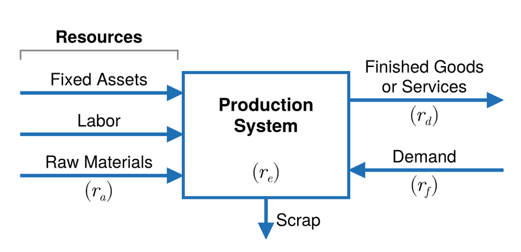

Figure 1: A production system: the resources it takes in, the finished goods or services it produces, the demand offered to it, and its scrap, with the rate of each flow and its capacity, $r_e$.

```julia
# Code block 1: a production system and its rates
bluec = colorant"#1f6fb5"               # the system and its flows
grayc = colorant"#7f7f7f"               # the bracket over the resources
fs = 17                                 # every label, as body text
fm = 21                                 # the rates, a size larger
function flow!(ax, x0, y0, x1, y1)      # a straight arrow from (x0, y0)
    arrows2d!(ax, [x0], [y0], [x1 - x0], [y1 - y0]; color = bluec,
              shaftwidth = 3.5, tipwidth = 16, tiplength = 16)
    return nothing
end
# Drawn compact, on the proportions of Lecture 1.3's figure, so that the
# labels and rate symbols are large against the drawing
fig = Figure(size = (520, 252), figure_padding = 2)
ax = Axis(fig[1, 1]; aspect = DataAspect())
hidedecorations!(ax)
hidespines!(ax)
limits!(ax, 0, 930, 0, 450)
poly!(ax, Rect(325, 95, 300, 227); color = :white, strokecolor = bluec,
      strokewidth = 3)                  # the production system
text!(ax, 475, 245; text = "Production\nSystem",
      align = (:center, :center), fontsize = 18, font = :bold)
text!(ax, 475, 140; text = L"(r_e)", align = (:center, :center),
      fontsize = fm)
inputs = ["Fixed Assets", "Labor", "Raw Materials"]
for (y, s) in zip([285, 210, 135], inputs)
    flow!(ax, 30, y, 325, y)            # the resources, in
    text!(ax, 172, y; text = s, align = (:center, :bottom),
          offset = (0, 4), fontsize = fs)
end
text!(ax, 172, 135; text = L"(r_a)", align = (:center, :top),
      offset = (0, -4), fontsize = fm)
lines!(ax, [30, 30, 315, 315], [345, 362, 362, 345]; color = grayc,
       linewidth = 1.5)                 # the bracket over the resources
text!(ax, 172, 362; text = "Resources", align = (:center, :bottom),
      offset = (0, 4), fontsize = fs, font = :bold)
flow!(ax, 625, 272, 905, 272)           # finished goods or services, out
text!(ax, 762, 272; text = "Finished Goods\nor Services",
      align = (:center, :bottom), offset = (0, 4), fontsize = fs)
text!(ax, 762, 272; text = L"(r_d)", align = (:center, :top),
      offset = (0, -4), fontsize = fm)
flow!(ax, 905, 145, 625, 145)           # demand, offered from the right
text!(ax, 762, 145; text = "Demand", align = (:center, :bottom),
      offset = (0, 4), fontsize = fs)
text!(ax, 762, 145; text = L"(r_f)", align = (:center, :top),
      offset = (0, -4), fontsize = fm)
flow!(ax, 475, 95, 475, 20)             # scrap, out the bottom
text!(ax, 475, 55; text = "Scrap", align = (:left, :center),
      offset = (10, 0), fontsize = fs)
fig
```

The production system in Fig. 1 is described by a set of rates (all in units $q/t$):

**$r_e$**

= effective production/service rate, the capacity of the production system

**$r_a$**

= input (arrival) rate of work $\left\{\begin{array}{l}\text{raw material, for goods production}\\\text{accepted demand, for a service system}\end{array}\right.$

**$r_d$**

= departure rate of demand satisfied by the production system

**$r_f$**

= offered demand, the rate of work presented to the system.

These rates satisfy $r_a \ge r_d$, with $r_a = r_d$ if there is no yield loss (true for most service systems); the shortfall $r_a - r_d$ is the yield loss, leaving the system as the scrap of Fig. 1. When the input is controlled, as in most of what follows, the system admits all offered demand and $r_f = r_a$; but offered demand can exceed what the system is able to admit, for example when raw material is limited, and then a decision arises over how much of it to take in ($r_f \ge r_a$), one not taken up here.

In Fig. 1, the capacity of the system is its effective rate, $r_e$. What arrives is raw materials if it is goods manufacturing, and what departs is the finished goods. The arrival rate and the departure rate do not have to be the same: some product can be scrapped during production. A service system does not really have scrap, since it is not producing goods, but it has customer abandonment instead. A customer who intended to use a service and sees a two-hour wait, at a motor vehicle office, say, with only an hour to spare, simply leaves. Finally there is the offered demand. In some periods the demand offered may be double the capacity, and if customers are not willing to wait, the system has to say that it cannot serve them: demand that is offered does not have to be accepted.

## 2. Service system design

A service system holds no inventory, so of the three buffers it has two, time and capacity, and its design is the trade-off between them. After the *Service system model*, the *Delay discount* evaluates the time buffer, the topic this section takes up in detail, and *Estimating cost data* lists the model’s cost inputs. A service’s queue empties every day, so it is never in steady state: *Queues that empty every day* estimates its cycle time by simulation, the recommended estimate; *Recursion by hand* checks it where peaks in demand exceed capacity; the *Number of servers* that maximizes total profit is chosen by the model’s objective, with the cycle time of each number simulated; and *Which estimate applies* sums up when each estimate of the cycle time is used.

### Service system model

Service systems, the first of the three kinds of production system designed here, do not carry finished goods inventory (FGI), and in the simple service system taken up here all customers eventually receive service (i.e., no abandonment), so $r_a = r_d$, there being no yield loss. The producer makes one decision, its production rate, also called its capacity or the design of the system. The control logic for the producer is to produce if a customer is waiting, and otherwise to shut down production. In the customer service process, a customer must wait for service to be produced, getting a discount in price based on wait time.

A service system carries no finished goods inventory, so inventory is off the table. All customers are assumed eventually to receive service, so customer abandonment is not modeled, because the model is a strategic one. The customers of the systems being modeled already know, more or less, what the cycle time will be; it is not unexpected. An operational problem would be different: after a spike in demand, a customer who arrives to a long line where normally there is no wait is a good candidate to walk away and abandon the service. A strategic model deals with the long term. A patient who calls a specialist for an appointment does not expect to be seen tomorrow, but perhaps in a month or two, depending on how important it is: the expectation is calibrated to the average cycle time. That is an important simplification, and with it a service system has no abandonment, and no scrap. The producer, the one designing and operating the service system, makes one decision, the production rate. Where the service is provided by people, each person is like a machine, so the one decision is how many doctors an office needs, or how many nail technicians, dentists, or barbers: the correct number of the people actually providing the service. Demand is also assumed to be fairly constant, with no peak and off-peak periods; those could be added, but they would make the model more complicated. The model is a barebones way of looking at a service system that gives the basic trade-offs, simple enough to keep in mind. Numbers can be put in to calculate an answer, but that is secondary to a way of thinking about the trade-offs and where to look to make a decision. That is also what makes the model useful beside an AI model: an answer that looks really good needs a ground truth to be judged against, and this model is a ground truth for production systems.

Model 1 states the service system as a model. Its assumption (d) is a queue empty at the beginning and end of each day, which is why its cycle time is estimated by simulation (*Queues that empty every day*).

**maximize:** total profit per hour of a service, the unit profit on the customers served, discounted for their wait, less the cost of its capacity

**solve for:**  
(a) capacity, the production rate of the service.

**subject to:** none

**assumptions:**  
(a) no inventory can be held;  
(b) every customer is served, with no abandonment;  
(c) revenue from each customer reduced for the time the customer waits, by no more than the unit profit;  
(d) no queue at the beginning or end of each day.

Model 1: Service system design

Model 1 formulation: Service system design

The capacity is the one that solves, with $TP_{SRV}$ the total profit ($/hr),

$$\max_{r_{e}} \; T P_{SRV} = ( p - c ) \, \overbrace{\bigl( 1 - g \, t_{CT}\mkern-1.5mu( r_{e} ) \bigr)}^{\text{time}} \, r_{d} - \overbrace{k \, r_{e}}^{\text{capacity}}
\tag{1}$$

where

**$r_{e}$**

= capacity of production system (units/hr)

**$p$**

= unit price ($/unit)

**$c$**

= unit operating cost ($/unit)

**$g$**

= delay discount factor (1/hr)

**$t_{CT}\mkern-1.5mu( r_{e} )$**

= cycle time of production system (hr)

**$r_{d}$**

= departure rate (units/hr)

**$k$**

= capital cost per unit of capacity ($/unit).

Eq. 1 maximizes total profit, and there is one for each of the three systems, service here, make-to-order in Sec. 3, and make-to-stock in Sec. 4. Its one knob is the capacity, in many cases the number of machines or, for a service system, the number of workers. The unit profit is the price minus the cost, $p - c$. Of the three buffers a production system has for dealing with variability, a service system has two, since inventory is off the table: time and capacity. Both are set by the one knob, the capacity chosen. The cycle time, how long a customer waits for the service, depends on the capacity: with one barber or one doctor, a customer probably waits a long time, and with two, three, or four the wait goes way down, as Lecture 1.3’s cycle-time estimate showed, the cycle time falling as capacity rises. That is the time term. The capacity term is what is paid for that capacity, and there is no free lunch: adding doctors raises the capacity cost. The trade-off is between increasing capacity to reduce the cycle time and the capacity cost that increase brings.

Assumption (c) bounds the discount. The factor $(1 - g \, t_{CT})$ falls in a straight line as the wait grows, and nothing in Eq. 1 stops it at zero: past a wait of $1/g$ it is negative, and the model would have the service lose more than the unit profit on each customer, as if the price had fallen below the unit cost. A customer facing such a wait would go elsewhere, which assumption (b) rules out, so the model holds only where the wait costs no more than the unit profit, $g \, t_{CT} \le 1$. The bound is on the discount, not on $g$ itself, a rate per unit of time that can exceed 1, and since $t_{CT}$ is the mean wait, it is the mean that is bounded: the last customers of a rush can wait longer than $1/g$. Models 2 and 3 make the same assumption.

### Delay discount

Lecture 6.2 (Sec. 2) introduced the delay discount, the share $g$ of the unit profit lost for each period a backorder waits (Eq. 2 in Lecture 6.2), and left open how $g$ is determined. In the model, the discount represents the reduction in unit operating profit for the time demand waits to be filled/completed, but it is easier to estimate the reduction in unit price, then convert it to profit. The reduction in price can be estimated using the “percent-reduction interval” method: given $t_g$, the time when a delay results in an $x_g$-percent reduction in the original price $p$, find the price discount factor, $g'$, the share of the price lost per unit of time:

$$g' \, t_{g} \, p = x_{g} \, p \Rightarrow g' \, t_{g} = x_{g} \Rightarrow g' = \frac{x_{g}}{t_{g}}
\tag{2}$$

where

**$t_g$**

= delay, the time over which the price is reduced by $x_g$ (hr)

**$x_g$**

= reduction in the original price over $t_g$, a fraction of $p$

**$g'$**

= discount factor of the unit price (1/hr).

Then the price reduction is converted to a unit profit reduction to get $g$:

$$\begin{aligned}
( p - c ) \, g &= p \, g' \\
( p - c ) \, g &= p \left( \frac{x_{g}}{t_{g}} \right) \Rightarrow \boxed{g = \frac{p \, x_{g}}{( p - c ) \, t_{g}}} , \quad \text{and} \quad t_{g} = \frac{p \, x_{g}}{( p - c ) \, g}
\end{aligned}
\tag{3}$$

with $g$ the delay discount factor (1/hr) of Eq. 1, the share of the unit profit lost per unit of time. It is important that $t_g$ should be in the same time units as $t_{CT}$.

Service system design is long term: the model is a strategic-planning tool that captures long-run economic trade-offs between capacity, delay, and value. The delay discount factor represents anticipated lead-time sensitivity, the reduction in perceived value of service when customers expect a long wait (e.g., future appointments, scheduled backlogs). Customer abandonment, a short-term behavioral effect, is not explicitly modeled; its average impact could be absorbed into a fixed yield parameter $y$ that reflects non-completions or no-shows.

The delay discount factor represents the reduction in unit operating profit for the time a demand waits to be filled. A reduction in profit is not how anyone actually thinks about a wait; the realistic way is the reduction in the unit price, converted to profit. At a quick-lube shop, a car can be driven in and out with an oil change within 30 or 40 minutes, and the customer pays a premium for that, perhaps $60 or $70. A shop that took bookings a week ahead, for a slot at 10 a.m. on a Wednesday, might do the same oil change for $25. The difference between paying $70 to have it right now and booking it is a measure of time sensitivity: a customer with little money is probably willing to be more flexible to get a low price, while one whose time is very valuable is willing to pay a premium. The delay discount captures that. The percent-reduction interval method converts the reduction in profit into a reduction in price, and the net of it is that the factor is calculated from $p$ times $x_g$, where $x_g$ is the reduction in the original price over some period of time, Eq. 3. It is exactly the percent-reduction interval that gave the obsolescence part of the inventory carrying rate in Lecture 3.3 (Eq. 13 in Lecture 3.3), applied to time instead of inventory.

Suppose a service advertises that a customer who waits an hour gets it for half of the $100 it costs, one who waits two hours gets it free, and one who waits four hours gets it free and is also paid $100 for the hassle. By Eq. 2, half off for one hour is $g' = 0.5/1 = 0.5$ an hour. Free after two hours is a 100% reduction, since the company now receives nothing where it was receiving the price, so $x_g = 1$ over $t_g = 2$ hours, again $g' = 1/2$. Paying the customer after four hours is a 200% reduction in the price, $x_g = 2$ over $t_g = 4$ hours, and again $g' = 1/2$. In the model, then, the three offers are exactly the same. In practice they almost certainly would not be, though which way they would differ is not clear; with the money to find out, a company would run an A/B test, a survey of customers, or a pilot study offering different options at different locations. The model captures enough of reality to make the high-level points, but it is not a fine-tuned instrument. It assumes the reduction is linear, continuing in a proportional manner, so that waiting one hour costs the same per hour as waiting two, which for people is not the case. The couple of Lecture 2.1 locating a home between two workplaces is the same point: for a hired truck driver one mile is the same as any other, so minimizing the distance is a good objective, but a couple would rather equalize the hassle of the commute than save money by having one of them do all the driving. Things in the real world are not proportional or linear. The delay discount assumes the world is linear and proportional because that makes the model easier.

Example 1: Delay discount factor

A service has a unit price of $p = \$100$ and a unit cost of $c = \$60$. Determine its price discount factor and its delay discount factor, $g'$ and $g$, for a low discount, if one year’s delay results in an 80% discount of the price, and for a high discount, if a 15-minute delay results in an 80% discount of the price.

Example 1(a): By hand

Compute both factors in each case with Eq. 2 and Eq. 3.

In the low case, the delay is $t_g = 1$ year and the reduction $x_g = 0.8$ of the price. The price discount factor is Eq. 2,

$$g' = \frac{x_g}{t_g} = \frac{0.8}{1} = 0.8 \text{ per yr}$$

and the delay discount factor is Eq. 3, with the year as the unit of time:

$$t_{g} = 1 \text{ yr } \Rightarrow g = \frac{p \, x_{g}}{( p - c ) \, t_{g}} = \frac{100 ( 0.8 )}{100 - 60} = 2$$

a factor of 2 per year: a profit-based factor more than twice the price-based one. In the high case, the delay of 15 minutes is put in hours, the unit of time of the total profit per hour, so $t_g = 15/60 = 0.25$ hr. The price discount factor is

$$g' = \frac{x_g}{t_g} = \frac{0.8}{0.25} = 3.2 \text{ per hr}$$

and the delay discount factor is

$$t_{g} = \frac{15}{60} = 0.25 \text{ hr } \Rightarrow g = \frac{100 ( 0.8 )}{( 100 - 60 ) \, 0.25} = 8$$

A customer willing to wait a year in the low case gets the service for 20% of its original price, and with years as the unit of time the delay discount factor is 2. A 15-minute delay that leaves the service worth only 20% of its price is something super critical, and with hours as the unit of time, 15 minutes is 0.25 hours and the factor is 8. What matters is that the high case’s analysis of total profit is per hour, whereas the low case’s total profit would be per year. Either way, the delay discount factors are determined.

The profit-based factor is the larger because what the objective needs is the reduction in the unit profit, $p - c$, but it is hard to ask anyone what the reduction in profit is, so a problem gives the reduction in the price received instead. That is why Eq. 3 has the ratio $p/(p - c)$, here $100/40$: it converts the information given as a decrease relative to the price into a decrease relative to the profit.

Each factor’s units are those of its delay, per year in the low case and per hour in the high, a Units check of Lecture 1.2, and in both cases $(p - c)\,g = p\,g'$, the conversion of Eq. 3.

Low discount: $g' = 0.8$ and $g = 2$ per year; high discount: $g' = 3.2$ and $g = 8$ per hour

Example 1(b): In code

Compute the same factors in Julia and compare them with part (a)’s.

Code block 2 repeats the calculation, the two delays in one vector:

```julia
# Code block 2: price and delay discount factors of Ex. 1
using Logjam                    # for prt, a labeled table
p = 100                         # $/unit, unit price
c = 60                          # $/unit, unit cost
xg = 0.8                        # share of the price lost over tg
tg = [1, 15/60]                 # yr and hr, the two delays
gp = xg ./ tg                   # 1/yr and 1/hr, price discount factor
g = p*xg ./ ((p - c) .* tg)     # 1/yr and 1/hr, delay discount factor
prt([tg gp g]; rows = ["low (yr)", "high (hr)"],
    cols = ["tg", "g'", "g"], row_title = "discount")
```

```
 discount    tg    g'  g
────────────────────────
 low (yr)  1.00  0.80  2
high (hr)  0.25  3.20  8
```

Code block 2 gives the four factors of part (a).

Low discount: $g'$ = 0.8 and $g$ = 2.0 per year; high discount: $g'$ = 3.2 and $g$ = 8.0 per hour

### Estimating cost data

The model needs three cost inputs, $p$, $c$, and $k$:

- **Unit price ($p$):** assumed given.
- **Unit operating cost ($c$):** *top-down*, from a known annual $OC$ and a known demand $F$, $c = OC/F$; or *bottom-up*, the sum of the raw material, labor, and energy cost per unit.
- **Unit capital cost ($k$):** the cost of a unit of capacity, estimated from the investment in it in Sec. 4 (*Capital cost*), since an investment in equipment is more a producer’s than a service’s.

### Queues that empty every day

In solving the service model, simulation is used for one thing only: to estimate the cycle time, the time a customer spends in a day’s queue. The service system itself is not simulated, as the inventory of Lecture 6.2 was, and the design, the number of servers, comes entirely through the model’s objective, its total profit. For a service, the default estimate of the cycle time should be either simulation of the day’s queue or, if done by hand, the recursion. Recursion should be properly thought of as the by-hand version. The steady-state cycle time is really more of a special case: most queues that empty every period have to be simulated or handled through recursion.

A queue that empties every day is never in steady state, so no steady-state estimate gives its wait. A day at the same rate every hour starts empty and is still building toward the steady-state average at closing, so the steady-state wait is an upper bound on the day’s average wait, as Lecture 1.3 (Sec. 8) found; a day with peaks above capacity carries an overflow from hour to hour that an average rate cannot see (Ex. 2). Simulation sees both.

A service system, whose customers cannot stay at the end of the day, essentially never reaches the steady state, the stationarity the factory-physics estimate needs. A course in factory physics deals mostly with the factory and hardly with services, so there it is not an issue, but a significant share of industrial engineers will work in settings such as health care, which are far more a service than goods manufacturing, and the service side matters. Most of the modeling carries over to a service very nicely. The one catch is that a service cannot be taken to run forever and reach steady state. What works well for its cycle time is simulation, though it is a bit of work, the kind of thing an undergraduate simulation course prepares for. Formulas that worked would be nice; an adjustment factor once tried did not hold up when it was tested, so simulation remained the method. Make-to-order is in that sense the easiest of the three models: it has no inventory, everything is made to order, and widgets do not mind staying when the doors shut at 5:00. They are there the next morning, everything as it was left, so the system effectively runs forever even though it shuts down each night, because the widgets stay on the line.

The cycle-time estimate of Lecture 1.3 has to assume that the system is stationary, a long-run average: a shop operating 24 hours a day, 365 days a year, never stopping, with its customers still arriving at three in the morning at the same rate as at the peak lunch hour. That is maybe not realistic for a barbershop, and relaxing it asks what happens if the shop operates only 10 hours a day.

Lecture 1.3 (Sec. 8) measured the effect on a barbershop, and its account is repeated here:

The same caveat shows up operationally. A goods-producing system carries work in process from shift to shift and, run long enough under stationary demand, approaches the steady-state averages the VUT formula reports; many service systems do not, clearing every day and starting each morning empty, so a short enough day is spent entirely in the start-up transient, where the steady-state estimate does not apply and simulation is the only recourse. This is the transient case Lecture 1.3 (Sec. 7) raised as a first-class reason to simulate. A barbershop open around the clock (8,760 hours per year) is stationary; one open only 10 hours a day is not, and there is little customer waiting at the start of each day even when utilization is high. A customer arrival rate that varies throughout the day is likewise nonstationary, and can be modeled with a *nonhomogeneous* Poisson process, using, for example, a different arrival rate each hour.

A short simulation of the barbershop ($r_e = 6$/hr, $c_e^2 = 0$, a deterministic 10-minute cut) makes the point (Table 4 in Lecture 1.3). Run around the clock for a full year (8,760 hr), the simulated cycle time in queue matches the steady-state estimate of Eq. 6 in Lecture 1.3; run only 10 hours a day, the queue never leaves its start-of-day transient and the average wait falls well short of the steady-state value, the more so the higher the utilization. Fig. 8 in Lecture 1.3 traces the same shortfall continuously: the simulated wait climbs toward the steady-state estimate only as the daily hours grow, a ten-hour service day reaching barely 70% of it.

On a computer, the day’s queue is simulated, to estimate its cycle time. Code block 3, `poissarr`, generates a day’s arrivals: totally random arrivals, a Poisson process, are generated at the peak rate, the largest of the periods’ rates, and each arrival in period $t$ is kept with probability $r_a\mkern-1.5mu(t)/\max r_a$, so the arrivals kept are a nonhomogeneous Poisson process (Lecture 1.3, Sec. 8), at each period’s own rate. Given a single rate, it generates the arrivals of `n` periods at that rate:

```julia
# Code block 3: Poisson arrival process
using Random                        # for randexp, exponential draws
function poissarr(lmb, n = 1)
    # lmb = n-element vector of arrival rates, where lmb[i] is the rate
    #       for time period i
    #   n = number of periods, if scalar lmb
    #   t = vector of variates, where t[j] between [(i-1), i) correspond
    #       to period i arrivals
    if n > 1 && length(lmb) > 1
        error("\"n\" > 1 only for scalar \"lmb\".")
    end
    lmax = maximum(lmb)             # the peak rate
    t = cumsum(randexp(ceil(Int, n*1.25*length(lmb)*lmax))/lmax)
    done = false
    while !done
        if t[end] > n*length(lmb)
            done = true
            t = t[t .< n*length(lmb)]
        else                        # extend by a quarter as many
            more = ceil(Int, n*0.25*length(lmb)*lmax)
            t = [t; t[end] .+ cumsum(randexp(more)/lmax)]
        end
    end
    if !isempty(t) && length(lmb) > 1   # Thin if nonhomogeneous
        rnd = rand(length(t))
        for i in 1:length(lmb)
            t[(i - 1 .<= t .< i) .& (rnd .> lmb[i]/lmax)] .= NaN
        end
        t = t[.!isnan.(t)]
    end
    return t
end
```

**1**

A quarter more interarrival times are drawn than the day’s expected number of arrivals at the peak rate, so one draw usually covers the day; the loop after it adds a quarter more only when it does not.

**2**

An arrival in period $i$ is set to `NaN`, to be dropped, unless its uniform draw is at most $r_a\mkern-1.5mu(i)/\max r_a$, so the arrivals kept in period $i$ are a Poisson process at that period’s own rate.

```
poissarr (generic function with 2 methods)
```

Code block 4, `qfifo`, serves them first come, first served: each customer in turn goes to the server that is free earliest, waits for it if it is busy, and departs after its service time. The system is empty at the start of the day, and every customer in it at closing is served:

```julia
# Code block 4: an m-server FIFO queue
function qfifo(a, s, m = 1)
    # a = n-element vector of arrival times (cumsum of interarrival times)
    # s = scalar, constant service time
    # m = number of identical servers
    # d = n-element vector of departure times
    n = length(a)
    d = zeros(n)
    # Time when m servers are first available
    server = a[1:min(m, n)]
    for i in 1:n
        # Select earliest available server
        timeavail, availserver = findmin(server)
        if timeavail > a[i]
            d[i] = server[availserver] + s    # Wait for server
        else
            d[i] = a[i] + s                   # Immediate service
        end
        server[availserver] = d[i]  # When server next available
    end
    return d
end
```

**1**

Each of the $m$ servers is first free at one of the first $m$ arrival times, so the first $m$ customers start service as they arrive.

```
qfifo (generic function with 2 methods)
```

Code block 5, `ctqsim`, simulates the day `nruns` times, with the random draws seeded so that they repeat, and returns the mean time in queue of $m$ servers over the days:

```julia
# Code block 5: the time in queue simulated over many days
using Statistics                    # for mean
function ctqsim(ra, te, m; nruns = 10_000, seed = 1)
    Random.seed!(seed)              # random draws, seeded to repeat
    CTq = zeros(nruns)              # hr, mean time in queue of each day
    for i in 1:nruns
        a = poissarr(ra)            # hr, the day's arrival times
        d = qfifo(a, te, m)         # hr, departure times
        CTq[i] = mean(d - a .- te)  # hr, time in queue
    end
    return mean(CTq)                # hr, mean time in queue over the days
end
```

```
ctqsim (generic function with 1 method)
```

### Recursion by hand

Where the arrival rate differs from hour to hour, the arrivals of some hours can exceed capacity, and the excess demand not served in an hour is carried into the next. The recursion follows that excess hour by hour. Like simulation, the recursion is used only to estimate the cycle time, here by hand. What makes the recursion work is that there have to be arrivals exceeding capacity for multiple periods to allow work to carry over. That then represents the majority of the cycle time: the overflow waiting time, which more than overwhelms the stochastic waiting within a period, which Eq. 5 leaves out.

A small day shows what the recursion does. Customers arrive at 5, 7, 20, 30, 4, 10, 15, and 5 an hour over the eight hours a shop is open, and the shop can serve 15 an hour. Hours 1 and 2 serve everyone. In hour 3, 20 arrive and 15 are served, so 5 are carried into hour 4, where 30 more arrive and 20 are carried on; in hours 5 to 7 fewer than 15 arrive, and the 20 are worked down to 9, then 4, and 4 again, until hour 8 clears them. Fig. 2 draws the day, and Table 3 sets it out hour by hour:

**Show the code that draws this figure**

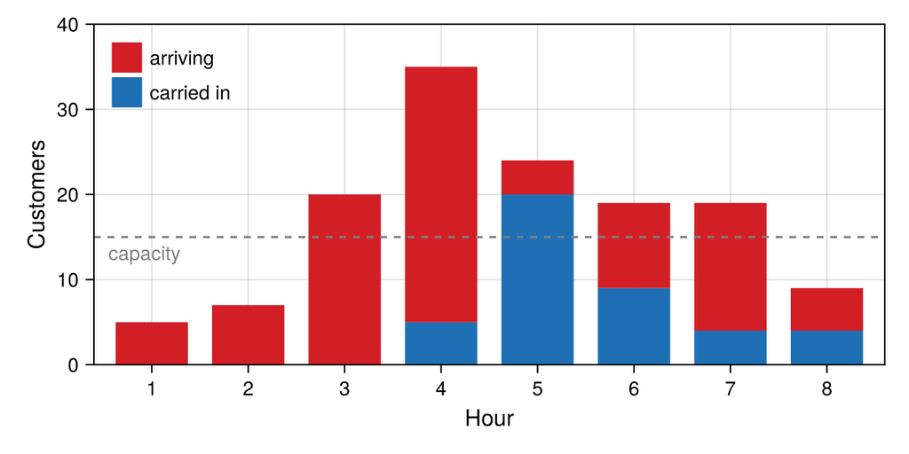

Figure 2: A small day hour by hour: the customers arriving in each hour, given, in red, on top of the customers carried in from the hour before, determined by Eq. 6, in blue, against a capacity of 15 customers an hour (dashed). What stands above the line in an hour is carried into the next.

```julia
# Code block 6: a small day hour by hour, against capacity
ra = [5, 7, 20, 30, 4, 10, 15, 5]   # per hr, arrival rate in hour t
re = 15                         # per hr, capacity
redc = colorant"#d21f26"        # given: the customers arriving
bluec = colorant"#1f6fb5"       # determined: the customers carried in
grayc = colorant"#7f7f7f"       # the capacity
n = length(ra)                  # hours open
qx = zeros(n)                   # customers, excess of each hour
for t in 1:n
    qx[t] = max(0, ra[t] + (t > 1 ? qx[t-1] : 0) - re)
end
cin = [0; qx[1:n-1]]            # carried in from the hour before
hrs = 1:n
fig = Figure(size = (600, 300))
ax = Axis(fig[1, 1]; xlabel = "Hour", ylabel = "Customers", xticks = hrs,
          xlabelsize = 15, ylabelsize = 15, xticklabelsize = 13,
          yticklabelsize = 13)
barplot!(ax, [hrs; hrs], [cin; ra]; stack = [fill(1, n); fill(2, n)],
         color = [fill(bluec, n); fill(redc, n)], gap = 0.25)
hlines!(ax, re; color = grayc, linestyle = :dash, linewidth = 1.5)
text!(ax, 0.55, re; text = "capacity", align = (:left, :top),
      offset = (0, -3), fontsize = 13, color = grayc)
axislegend(ax, [PolyElement(color = redc), PolyElement(color = bluec)],
           ["arriving", "carried in"]; position = :lt,
           framevisible = false, labelsize = 13)
xlims!(ax, 0.4, n + 0.6)
ylims!(ax, 0, 40)
fig
```

Table 3: A small day: in each hour $t$, the customers arriving, $r_a\mkern-1.5mu(t)$, plus those carried in, are served up to the capacity, $r_e$, and the rest are the excess $q_x\mkern-1.5mu(t)$ carried into the next hour.

| hour $t$ | 0 | 1 | 2 | 3 | 4 | 5 | 6 | 7 | 8 |
| --- | --- | --- | --- | --- | --- | --- | --- | --- | --- |
| $r_a\mkern-1.5mu(t)$ |  | 5 | 7 | 20 | 30 | 4 | 10 | 15 | 5 |
| $r_e$ |  | 15 | 15 | 15 | 15 | 15 | 15 | 15 | 15 |
| served |  | 5 | 7 | 15 | 15 | 15 | 15 | 15 | 9 |
| $q_x\mkern-1.5mu(t)$ | 0 | 0 | 0 | 5 | 20 | 9 | 4 | 4 | 0 |

Each customer carried from one hour into the next waits about an hour more, so the day’s excesses add up to its customer-hours of waiting, $0 + 0 + 5 + 20 + 9 + 4 + 4 + 0 = 42$, and over its 96 customers the average wait is $42/96 = 0.4375$ hr. The equations that follow say the same in general.

The recursion that estimates the time in queue by hand relates back to Little’s Law: it is essentially applying Little’s Law in a recursive manner. Little’s Law has been talked about twice already in the course so far, introduced in Lecture 1.3 (Sec. 3) and put to work in Lecture 6.1, for working stock (Eq. 4 in Lecture 6.1) and for the time a ton spends in a production plan (Ex. 3 in Lecture 6.1), but here is where it really is used as a way of handling a service whose queue empties every day, and it is repeated here:

$$WIP = TH \times CT, \qquad TH = \frac{WIP}{CT}, \qquad CT = \frac{WIP}{TH}
\tag{4}$$

where

**$TH$**

= throughput

**$WIP$**

= work-in-process

**$CT$**

= cycle time.

Each is an average over a production system: throughput is its output per time period, in units per hour or any other rate; work-in-process is the number of units of product it holds; and cycle time is the time each unit spends in it.

When Eq. 12 is used to estimate the cycle time in queue, the estimate assumes that the demand process is stationary and the result refers to a long-term average estimate. When the demand process is not stationary, a simple recursive procedure can be used to estimate the cycle time in queue, $CT_q$, via Little’s Law as applied to the total inter-period WIP in queue and the total of the expected arrivals occurring in each period:

$$CT_q = \frac{\text{Total } WIP_q}{\text{Total } TH} = \frac{\sum_{t=1}^{n+1} q_x\mkern-1.5mu(t)}{\sum_{t=1}^{n} r_a\mkern-1.5mu(t)}
\tag{5}$$

where $n$ is the number of periods with arrivals, $r_a\mkern-1.5mu(t)$ is the arrival rate for period $t$, and $q_x\mkern-1.5mu(t)$, the excess demand not served during period $t$, can be calculated for periods 1 to $n + 1$ as follows:

$$q_x\mkern-1.5mu(t) = \begin{cases} 0, & t = 0 \\ \max\{0,\ r_a\mkern-1.5mu(t) + q_x\mkern-1.5mu(t-1) - r_e\}, & t = 1, \dots, n \\ (n_x - 1)\left(q_x\mkern-1.5mu(n) - \dfrac{n_x \, r_e}{2}\right), & t = n + 1 \end{cases}
\tag{6}$$

where $n_x = \left\lceil q_x\mkern-1.5mu(n)/r_e \right\rceil$ is the number of periods required after the $n$ periods of normal operations to complete processing and $r_e$ is the (constant) service rate. (The service rate is assumed to be constant only to simplify the notation; different rates could be used to represent additional capacity that is available during peak periods of demand.)

In estimating $CT_q$, only the number of periods from the arrival of a demand to the period immediately preceding its processing is used to determine the queueing delay and any queueing that occurs during the period that processing occurs is ignored; thus, if $r_a\mkern-1.5mu(t) \le r_e$ for all periods, then $CT_q$ would be zero.

The excess demand in period $n + 1$, $q_x\mkern-1.5mu(n+1)$, represents the total number of periods of queueing required to complete the processing of the excess demand $q_x\mkern-1.5mu(n)$ in the system at the end of normal operations, not including the periods that the actual processing occurs. Since the final excess period is not included, $q_x\mkern-1.5mu(n+1)$ is equal to the $(n_x - 1)\,q_x\mkern-1.5mu(n)$ periods of queueing minus the cumulative impact of the $r_e$ units of demand processed in each of the $(n_x - 1)$ periods; or,

$$\begin{aligned}
q_x\mkern-1.5mu(n+1) &= (n_x - 1)\,q_x\mkern-1.5mu(n) - \left(\sum_{t=1}^{n_x - 1} t\right) r_e \\
&= (n_x - 1)\,q_x\mkern-1.5mu(n) - \frac{n_x(n_x - 1)}{2}\,r_e \\
&= (n_x - 1)\left(q_x\mkern-1.5mu(n) - \frac{n_x \, r_e}{2}\right)
\end{aligned}
\tag{7}$$

With excess demand, the throughput on a per-period basis is

$$TH = \frac{\sum_{t=1}^{n} r_a\mkern-1.5mu(t)}{n + n_x}
\tag{8}$$

Eq. 5 is the third form of Eq. 4, $CT = WIP/TH$, taken over a whole day: the excess carried from each period into the next, summed over the periods, is the total work in process in queue, and the day’s arrivals are the total throughput.

The by-hand method, the recursion, is not good for capacity planning. As capacity increases, eventually there are very few arrivals that exceed the capacity, so it would grossly underestimate cycle time. The capacity is given, and the recursion is used for things like validation or cases where the capacity is not actually being planned. Doing the recursion on a computer is never recommended, because a computer that can do it can just as well do the simulation. The issue is that the recursion looks only at capacity-related waiting, ignoring completely the stochastic aspect of it.

### Number of servers

The number of servers is chosen by its total profit, which has a ceiling. Simulation, or by hand the recursion, supplies only the cycle time of each number of servers; the choice among them is the objective’s. Since $r_{e} > r_{a}$ and, assuming $r_{a} = r_{d}$, $k \, r_{e} > k \, r_{d}$ in $T P$, and since the discount $1 - g \, t_{CT}$ is at most 1, the total profit of Eq. 1 is less than

$$T P_{UB} = ( p - c - k ) \, r_{d}
\tag{9}$$

One nice thing about the model is that it has an upper bound. The bound assumes that a customer is never delayed, so the cost of waiting goes away, and the best that can be done is the unit price minus the unit operating cost minus the capacity cost, the unit profit including capacity, applied to the output of good product. It is the best that could be done in a perfect world without any variability, and it puts a ceiling on the total profit. (Sec. 4 returns to it for make-to-stock, where the bound also assumes the product is never out of stock.)

Example 2: Barbershop

On an average day, customers are expected to arrive to a barbershop at rates of 5, 7, 20, 32, 6, 15, 45, and 12 per hour for the eight hours that the shop will be open. The arrivals during each hour are totally random and each haircut takes exactly 20 minutes. All customers in the shop at closing will continue to be processed. The shop has five barbers, each paid $w = \$20$ an hour whether or not there is a customer to serve. A haircut is $p = \$30$ and costs nothing more to give, $c = 0$, and a wait reduces its value by $x_g = 20\%$ every $t_g = 0.5$ hour. Determine the time a customer waits with five barbers, and the number of barbers that maximizes total profit.

Example 2(a): Five barbers

Determine the time in queue of five barbers by the recursion, by hand and in code, and by simulation, and their total profit by Eq. 1.

Five barbers, each taking 20 minutes a haircut, serve $r_e = m / t_e = 5/(1/3) = 15$ customers an hour. Starting from no excess, $q_x\mkern-1.5mu(0) = 0$, the excess of each hour is its arrivals plus the excess carried in, less the 15 the barbers can serve, Eq. 6; Table 4 carries it hour by hour, the last column the excess after closing, Eq. 7:

Table 4: The recursion of Eq. 6 on the barbershop’s day: in each hour $t$, the customers arriving, $r_a\mkern-1.5mu(t)$, plus the excess carried in, less the capacity, $r_e$, give the excess $q_x\mkern-1.5mu(t)$ carried into the next hour; hour 9’s is the queueing after closing.

| hour $t$ | 0 | 1 | 2 | 3 | 4 | 5 | 6 | 7 | 8 | 9 |
| --- | --- | --- | --- | --- | --- | --- | --- | --- | --- | --- |
| $r_a\mkern-1.5mu(t)$ |  | 5 | 7 | 20 | 32 | 6 | 15 | 45 | 12 |  |
| $r_e$ |  | 15 | 15 | 15 | 15 | 15 | 15 | 15 | 15 |  |
| $q_x\mkern-1.5mu(t)$ | 0 | 0 | 0 | 5 | 22 | 13 | 13 | 43 | 40 | 35 |

At closing, 40 customers are waiting, and serving them takes $n_x = \lceil 40/15 \rceil = 3$ hours, so the throughput of Eq. 8 is $TH = 142/(8 + 3) = 12.91$ an hour. The periods they wait after closing, not counting the hours they are served in, are the last excess, Eq. 7:

$$\begin{aligned}
q_x\mkern-1.5mu(9) &= (n_x - 1)\left(q_x\mkern-1.5mu(8) - \frac{n_x \, r_e}{2}\right) \\
&= (3 - 1)\left(40 - \frac{3 (15)}{2}\right) = 2 (17.5) = 35
\end{aligned}$$

The time in queue is Eq. 5, the total excess over the total arrivals:

$$CT_q = \frac{0 + 0 + 5 + 22 + 13 + 13 + 43 + 40 + 35}{5 + 7 + 20 + 32 + 6 + 15 + 45 + 12} = \frac{171}{142} = 1.2042 \text{ hr}$$

and the cycle time adds a haircut, $t_{CT} = CT_q + t_e = 171/142 + 1/3 = 1.5376$ hr.

With no operating cost, $c = 0$, the delay discount factor of Eq. 3 is the price’s own, $g = x_g / t_g = 0.2/0.5 = 0.4$ per hour. The capacity cost is the barbers’ wages: a barber provides $1/t_e = 3$ haircuts an hour of capacity for $w = \$20$ an hour, so $k = w \, t_e = \$6.67$ per unit, and $k \, r_e = w \, m$. The day’s 142 customers over its 8 hours are a departure rate of $r_d = 142/8 = 17.75$ an hour, and the total profit of five barbers is Eq. 1:

$$\begin{aligned}
TP &= ( p - c ) ( 1 - g \, t_{CT} ) \, r_d - w \, m \\
&= 30 \bigl( 1 - 0.4 (171/142 + 1/3) \bigr) (17.75) - 20 (5) \\
&= \$105.00 \text{ per hr}
\end{aligned}$$

Code block 7 sets the barbershop’s data, one value to a line:

```julia
# Code block 7: the barbershop's data
ra = [5, 7, 20, 32, 6, 15, 45, 12]   # per hr, arrival rate in hour t
@show te = 20/60                # hr, time of a haircut
p = 30                          # $/haircut, price
c = 0                           # $/haircut, operating cost
w = 20                          # $/hr, a barber's wage
@show k = w*te                  # $/unit, cost of a unit of capacity
xg = 0.2                        # share of the price lost over tg
tg = 0.5                        # hr, delay
@show g = p*xg/((p - c)*tg)     # 1/hr, delay discount factor
@show rd = sum(ra)/length(ra);  # per hr, departure rate, the day's mean
```

```
te = 20 / 60 = 0.3333333333333333
k = w * te = 6.666666666666666
g = (p * xg) / ((p - c) * tg) = 0.4
rd = sum(ra) / length(ra) = 17.75
```

No Logjam function computes Model 1, so its implementation is written out here, the total profit of Eq. 1 with $m$ barbers:

Model 1 implementation: Service system design

```julia
# Model: service system design, the number of servers
function TPsrv(m, CT = ctqsim(ra, te, m) + te)
    return (p - c)*(1 - g*CT)*rd - k*m/te
end
```

**1**

The cycle time is the day’s time in queue simulated by `ctqsim`, plus a haircut, unless another estimate is given.

**2**

Capacity is $r_e = m / t_e$, so the capital cost is $k \, m / t_e = w \, m$, the barbers’ wages.

```
TPsrv (generic function with 2 methods)
```

Code block 8 checks part (a)’s time in queue with the recursion, `ctexcess`, and sets beside it the time in queue simulated by `ctqsim` over 10,000 days, with the total profit each gives:

```julia
# Code block 8: five barbers, by the recursion and by simulation
# Queue time of excess demand makes up the majority of the queue time
# for terminating non-stationary arrival processes.
function ctexcess(ra, re)
    n = length(ra)                  # periods with arrivals
    qx = zeros(n + 1)               # excess demand not served in period t
    for t in 1:n
        qx[t] = max(0, ra[t] + (t > 1 ? qx[t-1] : 0) - re)
    end
    nx = ceil(Int, qx[n]/re)        # periods to finish qx(n) after n
    qx[n+1] = (nx - 1)*(qx[n] - nx*re/2)   # queueing while they finish
    return sum(qx)/sum(ra)          # hr, time in queue
end
m = 5                                   # barbers
@show CTqrec = ctexcess(ra, m/te)       # hr, by the recursion
@show CTqsim = ctqsim(ra, te, m)        # hr, by simulation
@show TP5rec = TPsrv(m, CTqrec + te)    # $/hr, with the recursion's
@show TP5 = TPsrv(m, CTqsim + te);      # $/hr, with the simulated
```

```
CTqrec = ctexcess(ra, m / te) = 1.204225352112676
CTqsim = ctqsim(ra, te, m) = 1.2288009077030624
TP5rec = TPsrv(m, CTqrec + te) = 105.00000000000001
TP5 = TPsrv(m, CTqsim + te) = 99.76540665924769
```

The recursion reproduces part (a)’s 1.2042 hr and $105.00, a Source check of Lecture 1.2. The simulated time in queue, 1.2288 hr, is within 0.025 hr of the recursion’s, an independent route agreeing, a Triangulate check of Lecture 1.2: with five barbers, the overflow carried from hour to hour is most of the wait, and it is what the recursion counts.

$CT_q$ = 171/142 = 1.2042 hr by the recursion and 1.2288 hr by simulation; $TP$ = $105.00 per hour by hand, $99.77 with the simulated time

Example 2(b): Number of barbers

Determine the total profit of five to twelve barbers by Model 1, each one’s cycle time simulated, and the number that maximizes it.

Code block 9 tries each number of barbers in turn, its cycle time simulated, with the recursion’s beside it for comparison:

```julia
# Code block 9: five to twelve barbers, and the best
ms = 5:12                                        # barbers
CTsim = [ctqsim(ra, te, m) for m in ms] .+ te    # hr, by simulation
CTrec = [ctexcess(ra, m/te) for m in ms] .+ te   # hr, by the recursion
TPsim = TPsrv.(ms, CTsim)                        # $/hr, total profit
TPrec = TPsrv.(ms, CTrec)                        # $/hr, by the recursion
prt([CTsim TPsim CTrec TPrec]; rows = ms, row_title = "m", fracdig = 4,
    cols = ["CT sim", "TP sim", "CT rec", "TP rec"])
TPᵒ, iᵒ = findmax(TPsim)                         # $/hr, the best profit
@show mᵒ = ms[iᵒ]                                # barbers, the best
@show mrec = ms[argmax(TPrec)]                   # barbers, by recursion
@show TPUB = (p - c - k)*rd;                     # $/hr, the upper bound
```

```
 m  CT sim    TP sim  CT rec    TP rec
──────────────────────────────────────
 5  1.5621   99.7654  1.5376  105.0000
 6  0.9923  201.1391  0.8756  226.0000
 7  0.7151  240.1740  0.6854  246.5000
 8  0.5834  248.2321  0.6009  244.5000
 9  0.5033  245.2919  0.5164  242.5000
10  0.4490  236.8526  0.4531  236.0000
11  0.4118  224.7959  0.4178  223.5000
12  0.3862  210.2442  0.3967  208.0000
mᵒ = ms[iᵒ] = 8
mrec = ms[argmax(TPrec)] = 7
TPUB = ((p - c) - k) * rd = 414.1666666666667
```

The total profit is greatest with 8 barbers, $248.23 an hour, below the bound of Eq. 9, $414.17, a Bounds check of Lecture 1.2. Had the total profit been maximized with the recursion’s cycle times, it would have chosen 7 barbers: the recursion counts only the overflow above capacity, which each barber added shrinks, and not the random wait within each hour, so it is a check at a given capacity, and the capacity is chosen with each one’s cycle time simulated. Fig. 3 draws the total profit of each number of barbers:

**Show the code that draws this figure**

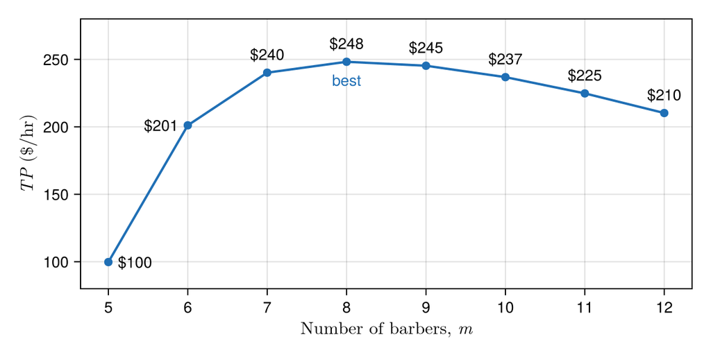

Figure 3: Total profit of the barbershop of Ex. 2 for five to twelve barbers, each one’s cycle time simulated, determined by Eq. 1, in blue, with the best number labeled.

```julia
# Code block 10: total profit against the number of barbers
bluec = colorant"#1f6fb5"       # a determined series
fig = Figure(size = (600, 300))
ax = Axis(fig[1, 1]; xlabel = L"\text{Number of barbers, } m",
          ylabel = L"TP \text{ (\$/hr)}", xticks = ms,
          xlabelsize = 15, ylabelsize = 15, xticklabelsize = 13,
          yticklabelsize = 13)
scatterlines!(ax, ms, TPsim; color = bluec, markersize = 10,
              linewidth = 2)
lbl = "\$" .* string.(round.(Int, TPsim))
# each label on the side of its point that the lines leave clear
als = [(:left, :center); (:right, :center); fill((:center, :bottom), 6)]
offs = [(8, 0); (-8, 0); fill((0, 8), 6)]
for i in eachindex(ms)
    text!(ax, ms[i], TPsim[i]; text = lbl[i], align = als[i],
          offset = offs[i], fontsize = 13)
end
text!(ax, mᵒ, TPᵒ; text = "best", align = (:center, :top),
      offset = (0, -8), fontsize = 13, color = bluec)
ylims!(ax, 80, 280)
fig
```

$m^* =$ 8 barbers; $TP^*$ = $248.23 per hour, against $99.77 with five; with the recursion’s cycle times, 7 barbers

### Which estimate applies

Which estimate of the cycle time applies is determined from the problem statement, by whether the queue carries over from one period to the next and by how the arrival rate varies against capacity, as Table 5 sets out. For a service, whose queue empties every day, the better approach is just to simulate the day’s queue to estimate the cycle time, because that way it handles both the waiting due to capacity issues and also waiting due to stochastic variation; it is the recommended approach, so the by-hand recursion is really a by-hand validation technique. The recursion sees only the waiting due to capacity, so it is not a way to choose the capacity. A queue carries over where work in process is kept from shift to shift, as in the make-to-order and make-to-stock designs of Secs. 3 and 4, and only there, with arrivals at the same rate every hour, does a steady-state estimate apply, the analytical estimate of Sec. 3:

Table 5: Which cycle-time estimate applies, by whether the queue carries over from one period to the next and by the arrival rate.

| Queue | Arrival rate | Estimate | Check by hand |
| --- | --- | --- | --- |
| empties daily | above capacity for several periods | simulation | recursion, Eq. 5 |
|  | never above capacity | simulation | none: recursion gives 0 |
| carries over | same rate every hour | steady state | analytical, Eq. 12 |

## 3. Make-to-order design

A make-to-order producer, like a service, holds no finished goods, but it makes goods, and some of what it makes is scrapped. The *Make-to-order model* is the service model of Sec. 2 with yield loss added, an aside here, and the analytical estimate of its cycle time in place of the simulated day. *Cycle time* takes that estimate up in detail, the main topic of this section, since it holds for a producer whose work in process carries over from one day to the next, make-to-order and make-to-stock alike; *One fast machine* derives its closed form for one machine whose rate is chosen; and Ex. 3 designs a make-to-order producer, by a search over the number of machines and by the closed form. Here, as in Sec. 2, the cycle time is only an input: the simulated day of Sec. 2 estimated a cycle time and nothing more, and the design comes through the model’s objective.

### Make-to-order model

A make-to-order system brings in one aspect that service systems could leave off the table: scrap. For a service, the departure rate and the arrival rate can safely be taken as equal, but in producing goods, depending on the complexity of the production process, there can be significant scrap, the defects of a molding process, say. Each production process has a typical characteristic yield. Semiconductor wafer fabrication tries to get its yield as high as it can be, but it is never 100%; it is always strictly less. By the end of a very long processing, the cost of operating the facility may have put millions of dollars into an expensive product, and one mistake can cause all of that work in process to be disposed of, with very little salvage value. For some industries the loss is very significant, so a make-to-order system cannot be assumed, as a service was, to have no yield loss. Yield loss is the one thing added to go from service systems to make-to-order; otherwise the same model applies. Neither a service system nor a make-to-order system carries inventory, since in make-to-order everything is customized, and that is what makes both easy to work with. Make-to-stock, in Sec. 4, brings inventory back, and with it the Poisson formulas of Lecture 6.2’s base stock: harder than make-to-order, though easier than simulating a service whose queue is not in steady state, a matter of degree. The sweet spot is make-to-order, where the factory-physics estimates of Lecture 1.3 can be plugged in to get good numbers for all of the interactions and dynamics.

Model 2 states make-to-order design as a model. It is a variant of Model 1 rather than a generalization: it adds yield loss, and its queue carries over from one day to the next where a service’s empties every day, so a service is not simply make-to-order with no yield loss, $y = 1$. Yield loss is assumed to occur only after a unit is produced, so a unit that is ultimately scrapped still takes its full process time on a machine. The assumption is conservative: a defect found before or during production would use less capacity, and assuming that every unit is produced keeps the analysis simple. What Model 2 changes in Model 1 is shown against it:

**maximize:** total profit per hour of a serviceproducer, the unit profit on the customers servedgood units produced, discounted for their wait, less the cost of its capacity

**solve for:**  
(a) capacity, the production rate of the serviceproducer.

**subject to:** none

**assumptions:**  
(a) no inventoryfinished goods inventory can be held, each unit being made to a customer’s order;  
(b) every customer is served, with no abandonment;  
(c) revenue from each customer reduced for the time the customer waits, by no more than the unit profit;  
(d) no queue at the beginning or end of each day.queue carried over from one day to the next, with work arriving at the same rate every hour;  
(e) yield loss after production: only a yield fraction of the units produced is good, the rest scrapped once produced, so work arrives at the departure rate of good units over the yield.

Model 2: Make-to-order design

Variant of Model 1: Service system design

Model 2 formulation: Make-to-order design

The capacity is the one that solves, with $TP_{MTO}$ the total profit ($/hr),

$$\underset{r_{e}}{\max} \; T P_{MTO} = ( p - c ) \, \overbrace{\bigl( 1 - g \, t_{CT}\mkern-1.5mu( r_{e} ) \bigr)}^{\text{time}} \, r_{d} - \overbrace{k \, r_{e}}^{\text{capacity}}
\tag{10}$$

with the other symbols, the capacity of production system $r_e$, the unit price $p$, the unit operating cost $c$, the delay discount factor $g$, and the capital cost per unit of capacity $k$, as in Model 1’s formulation, and

**$t_{CT}\mkern-1.5mu( r_{e} )$**

= cycle time of production system, Eq. 12 at $r_a = r_d / y$ (hr)

**$r_{d}$**

= departure rate of good units (units/hr).

Yield loss enters the model as an aside: the yield relates the rates of a workstation, as in Lecture 1.3 (Sec. 5). The yield fraction $y$ is the share of the work produced that is nondefective, so the output (departure) rate of nondefective work is the yield times the input (arrival) rate of work, and it can be no more than the offered demand:

$$r_{d} = y \, r_{a} \leq r_{f}$$

To depart at a desired rate of good units, $r_d$, work must therefore arrive at the departure rate over the yield,

$$r_{a} = \frac{r_{d}}{y}
\tag{11}$$

and the difference between the input and the output is the scrap rate of defective work:

$$r_{s} = r_{a} - r_{d} = r_{a} ( 1 - y )$$

Yield loss is really unavoidable for a production system, and yield is the key quantity: the long-run average percentage of nondefective parts. In any particular hour of operation there may be no defectives at all, but over a period of time some percentage of the items is defective. A yield of 0.8 means that on average 80% of the product is nondefective; any one hour more likely has no defectives, but added up over time, 20% of the items are scrap. In the production system, the difference between the arrival rate of work and the departure rate of good product is the rate at which scrap is produced. The calculation is straightforward. A system is wanted that produces so much good product every hour, and with a yield below 100%, $y$ is less than one in the denominator of Eq. 11, which bumps up the arrival rate: producing 100 good units takes more than 100 units of raw material starting production in the system, to account for the ones that will end up scrapped.

Eq. 10 is effectively the same equation as Eq. 1, with one difference underneath it. For a service system, the departure rate equals the arrival rate; for a make-to-order system, $r_d$ is the departure rate of good product, the only product the producer is paid for. Inside the system, though, the cycle time depends on the utilization, and the utilization, $u = r_a \, t_e / m$, includes the arrival rate. With some yield loss, $y$ less than one, the arrival rate exceeds the departure rate, so the producer has to provide capacity for the units that will be scrapped, and they increase the cycle time, because units have to wait even if they are ultimately to be scrapped. As the cycle time increases, the delay discount reduces the overall profitability. By including yield, the model captures the impact on profitability of different yield rates.

### Cycle time

In the total profit of Eq. 1, and of the make-to-order model above, the factor $( 1 - g \, t_{CT} )$ is the discount applied to unit profit due to delay estimated by cycle time, with $g$ the delay discount factor, a rate per unit of time that is not bounded by 1 itself (Ex. 1 has 2 per year and 8 per hour); what is bounded is the discount, $g \, t_{CT} \le 1$, so that a wait never costs more than the unit profit, as assumption (c) of each model states. The cycle time $t_{CT}\mkern-1.5mu( r_{e} )$ requires $r_{e} > r_{a} \geq r_{d}$ so that all demand is satisfied, and it is the sum of a queueing time and a process time:

$$\begin{aligned}
t_{CT}\mkern-1.5mu( r_{e} ) &= \underbrace{t_{C T_{q}}}_{\text{queuing time}} + \underbrace{t_{e}}_{\text{process time}} \\
&= \boxed{\left( \frac{c_{a}^{2} + c_{e}^{2}}{2} \right) \left[ \frac{u^{\sqrt{2 ( m + 1 )} - 1}}{m \, ( 1 - u )} \right] t_{e} + t_{e}}
\end{aligned}
\tag{12}$$

where

**$u$**

= utilization

= $r_{a} / r_{e} = r_{a} \, t_{e} / m$

**$t_{e}$**

= effective process time

= $m / r_{e}$ $= t_0 / A$, with the natural process time $t_0$ and the availability $A$ of Lecture 1.3 (Sec. 5)

**$m$**

= number of identical machines.

**$c_{a}^{2}$**

= squared coefficient of variation of demand

**$c_{e}^{2}$**

= squared coefficient of variation of processing.

Even when the shop closes at 5:00, the widgets being produced for a customer’s order are still there in the morning when the shop opens up. In terms of steady state, that is a lot more reasonable, so for make-to-order the factory-physics estimates can be used, and in that setting, where steady state can reasonably be assumed, they work pretty well.

Eq. 12 is Lecture 1.3’s estimate for a workstation of $m$ identical machines (Eq. 7 in Lecture 1.3), its queueing time with the process time added. It is a steady-state estimate, so it holds for make-to-order, and for the make-to-stock design of Sec. 4, whose work in process carries over from one day to the next, and not for a service, whose queue empties every day (*Queues that empty every day*, Sec. 2). A steady state needs $u < 1$, work arriving more slowly than the machines can process it. Capacity is added in whole machines, $r_e = m / t_e$, so the design is a search over $m$, starting from the fewest machines that keep $u < 1$, Lecture 1.3’s minimum (Sec. 5), repeated here.

The **throughput-feasible minimum** number of identical machines at the workstation is the fewest whose combined effective capacity (service rate) *strictly exceeds* the arrival rate of work, $r_a = r_d / y$ by Eq. 11. It is found by a **machine-hours** accounting, a general method of determining resource requirements (the resources can be machines, people, etc.) that can also be used to determine operating costs for economic justification. Over $H$ hours of operation, the available machine hours $mH$ split into processing, repair, and idle hours, and the minimum number of machines is the machine hours needed to meet demand divided by the productive hours per machine:

$$\begin{aligned}
m_{\min} &= \left\lfloor \frac{\text{machine hours needed to meet demand}}{\text{productive hours per machine}} + 1 \right\rfloor \\
&= \left\lfloor \frac{r_a \, t_0 \, H}{A \, H} + 1 \right\rfloor
= \left\lfloor r_a \frac{t_0}{A} + 1 \right\rfloor
= \lfloor r_a \, t_e + 1 \rfloor ,
\end{aligned}
\tag{13}$$

with $t_e = t_0 / A$, the effective process time of Eq. 12. The $+1$ inside the floor is what makes the capacity strictly exceed the arrival rate: where $r_a \, t_e$ is a whole number, rounding it up would give $u = 1$, and the minimum is one machine more. Yield loss raises the arrival rate of work, so the minimum rises as the yield falls, as Ex. 3(b) finds. Below the minimum the utilization is 1 or more and Eq. 12 means nothing, so the searches of the make-to-order and make-to-stock implementations start at $m_{\min}$. Code block 11 writes Eq. 12 as a function of the number of machines:

```julia
# Code block 11: the cycle time of m machines
function tct(m; ra = ra, te = te, ca2 = ca2, ce2 = ce2)
    u = ra*te/m                 # utilization
    u < 1 || error("utilization $u: $m machine(s) cannot keep up")
    CTq = ((ca2 + ce2)/2)*(u^(sqrt(2(m + 1)) - 1)/(m*(1 - u)))*te
    return CTq + te             # hr, cycle time in queue and in process
end
```

**1**

Eq. 12 needs a steady state, which needs $u < 1$; below $m_{\min}$ of Eq. 13 the estimate is meaningless, so the function refuses it rather than return a number.

```
tct (generic function with 1 method)
```

### One fast machine

Where the rate of a single machine can itself be chosen, rather than the number of machines, and both the arrivals and the processing are completely random, the design has a closed form. For such an M/M/1 station, Lecture 1.3 (Sec. 7) found the cycle-time estimate exact (Eq. 6 in Lecture 1.3), and Eq. 12 with $m = 1$ is that estimate. The design assumes Poisson arrivals, practical worst-case process variability (squared coefficient of variation, SCV = 1), and $r_a = r_d$ (no scrap, as in a make-to-order system). With one machine, $u = r_d / r_e$ and $t_e = 1 / r_e$, and the cycle time is

$$\begin{aligned}
t_{CT}\mkern-1.5mu(r_e) &= \left(\frac{c_a^2+c_e^2}{2}\right)\left(\frac{u}{1-u}\right)t_e + t_e \\
&= \frac{1+1}{2}\left(\frac{r_d/r_e}{1-(r_d/r_e)}\right)\frac{1}{r_e} + \frac{1}{r_e} \\
&= \left(\frac{r_d}{r_e - r_d}\right)\frac{1}{r_e} + \frac{1}{r_e} = \frac{1}{r_e - r_d}
\end{aligned}
\tag{14}$$

Substituted into Eq. 1, which with no scrap is the make-to-order producer’s total profit as well, the total profit is a function of the capacity alone,

$$TP(r_e) = (p-c)\left[1 - g\,t_{CT}\mkern-1.5mu(r_e)\right]r_d - k\,r_e$$

and with Eq. 14 its derivative is

$$\frac{dTP(r_e)}{dr_e} = \frac{d}{dr_e}\left[ (p - c) \left( 1 - \frac{g}{r_e - r_d} \right) r_d - k \, r_e \right] = \frac{(p - c) \, g \, r_d}{(r_e - r_d)^2} - k$$

which is zero where $(r_e - r_d)^2 = (p - c) \, g \, r_d / k$. The second derivative, $-2 (p - c) \, g \, r_d / (r_e - r_d)^3$, is negative for every $r_e > r_d$, so that point is the maximum:

$$\frac{dTP(r_e)}{dr_e} = 0 \Rightarrow \boxed{r_e^* = r_d + \sqrt{\frac{(p-c)\,g\,r_d}{k}}}
\tag{15}$$

**WarningManagerial insight only**

Eq. 15 only provides “managerial insights,” since the assumptions needed to get an analytical optimal solution usually are unrealistic.

Poisson arrivals are a reasonable assumption. The one not terribly realistic assumption is the process variability: rather than a low, a high, or an average between the two, the process is given the practical worst-case variability, its upper bound, an SCV of 1. The only reason to do that is that with it the total profit can be differentiated, the derivative set equal to zero, and the optimal rate solved for, a closed-form equation for the optimal production rate. With any other SCV it cannot be found analytically, only numerically. That is what makes a question like Ex. 3(c) answerable by hand on an exam, by assuming the upper-bound variability of an SCV of 1 for the process. It is also why Eq. 15 only provides managerial insight, since the assumptions needed to get an analytical optimal solution are usually unrealistic. Papers written for managers offer such closed forms for the insight they give into a problem, and they rarely carry that warning; this one does, because it is not realistic. Without the closed form, the answer takes a few lines of code, the search of Ex. 3(a), which is no great effort. So the closed form is not to be used as a general tool.

Example 3: Machines for make-to-order producer

A make-to-order producer sells each unit for $p = \$30$, at a unit operating cost of $c = \$20$, and a wait reduces the value of a unit by $x_g = 20\%$ every $t_g = 0.5$ hour. Orders arrive at random, $c_a^2 = 1$, and the producer is to make $r_d = 10$ good units an hour. Each unit takes exactly $t_0 = 10$ minutes on a machine, $c_0^2 = 0$, the machines never fail, and capacity costs $k = \$1$ per unit, so a machine costs $6 an hour. With every unit good, $y = 1$, determine the total profit with two machines and the number of machines that maximizes it; then determine how the utilization and the best number of machines move as the yield falls to 0.9, 0.8, and 0.7. Finally, for a producer of custom fixtures made to order with no scrap, determine which of two designs to use by the closed form of Eq. 15.

Example 3(a): Two machines and the best number

Determine the total profit with two machines at $y = 1$ by Model 2, and the number of machines that maximizes it.

Unlike the barbershop of Ex. 2, whose queue empties every day, the producer’s queue carries over from one day to the next, so its cycle time is the steady-state estimate of Eq. 12. The make-to-order calculation is the cycle-time calculation of Lecture 1.3 with the cost data added. The unit price, the unit cost, the unit capital cost, and the delay discount come first, so that the delay discount factor can be plugged into the total profit at the end; the rest is the cycle-time calculation. The one quantity new to make-to-order is the yield. With a yield of one, the arrival rate and the departure rate are the same; otherwise the arrival rate is the desired departure rate, 10 an hour, divided by the yield, and with less than 100% yield it is higher. That higher arrival rate feeds into the cycle-time calculation, giving a proper accounting of the capacity spent producing what is ultimately scrapped. Everything squares: there is no free lunch.

Code block 12 sets the data, one value to a line, the cost data first, with an availability of 1, since the machines never fail:

```julia
# Code block 12: the make-to-order producer's data
p = 30                          # $/unit, unit price
c = 20                          # $/unit, unit operating cost
k = 1                           # $/unit, unit capital cost
tg = 0.5                        # hr, delay
xg = 0.2                        # share of the price lost over tg
@show g = p*xg/((p - c)*tg)     # 1/hr, delay discount factor
y = 1                           # yield
rd = 10                         # units/hr, departure rate of good units
@show ra = rd/y                 # units/hr, arrival rate of work
ca2 = 1                         # arrival SCV
@show t0 = 10/60                # hr, natural process time
c02 = 0                         # natural process SCV
A = 1                           # availability, the machines never fail
@show te = t0/A                 # hr, effective process time
@show ce2 = c02;                # effective process SCV, with A = 1
```

**1**

Lecture 1.3’s effective process SCV with failures, Eq. 9 in Lecture 1.3, is $c_e^2 = c_0^2 + (1 + c_r^2)\,A(1 - A)\,\text{MTTR}/t_0$; with an availability of 1 its failure term is zero, and $c_e^2 = c_0^2$.

```
g = (p * xg) / ((p - c) * tg) = 1.2
ra = rd / y = 10.0
t0 = 10 / 60 = 0.16666666666666666
te = t0 / A = 0.16666666666666666
ce2 = c02 = 0
```

No Logjam function computes Model 2 either, so its implementation is written out here. Its total profit is Model 1’s with the cycle time of `tct` at the arrival rate of work, $r_d / y$, in place of the cycle time simulated from the day’s queue, and the best number of machines is found by brute force, from the minimum up while the total profit still rises:

Model 2 implementation: Make-to-order design

```julia
# Model: make-to-order design, the number of machines by search
# Total profit with m machines at yield y, and the best m
TPmto(m; y = y, g = g, k = k) =
    (p - c)*(1 - g*tct(m; ra = rd/y))*rd - k*m/te
function maxTPmto(; y = y, g = g, k = k)
    m = floor(Int, rd/y*te + 1) # m_min, at the arrival rate of work
    best = (TPmto(m; y, g, k), m)
    while TPmto(m + 1; y, g, k) > best[1]
        m += 1
        best = (TPmto(m; y, g, k), m)
    end
    return best
end
```

**1**

`tct` is Code block 11’s, its utilization at the arrival rate of work, $r_a = r_d / y$, while the producer is paid only for the good units, $r_d$. The yield, the delay discount factor and the unit capital cost are keyword arguments, each the example’s unless another is given.

```
maxTPmto (generic function with 1 method)
```

Code block 13 evaluates two machines, one quantity to a line, and then finds the best number:

```julia
# Code block 13: two machines, one quantity at a time, and the best
m = 2                           # machines
@show mmin = floor(Int, ra*te + 1)   # minimum number of machines
@show u = ra*te/m               # utilization
@show CT = tct(m)               # hr, cycle time at the workstation
@show CTq = CT - te             # hr, cycle time in queue
@show WIPq = ra*CTq             # units, work in process in queue
@show WIP = ra*CT               # units, work in process at the station
@show WIP - WIPq                # units, work in process on the machines
@show re = m/te                 # units/hr, capacity
@show TP = TPmto(m)             # $/hr, total profit
TPᵒ, mᵒ = maxTPmto();           # $/hr and machines, the best
@show TPᵒ
@show mᵒ;
```

```
mmin = floor(Int, ra * te + 1) = 2
u = (ra * te) / m = 0.8333333333333333
CT = tct(m) = 0.3586076010734883
CTq = CT - te = 0.19194093440682167
WIPq = ra * CTq = 1.9194093440682167
WIP = ra * CT = 3.5860760107348835
WIP - WIPq = 1.6666666666666667
re = m / te = 12.0
TP = TPmto(m) = 44.967087871181405
TPᵒ = 59.43956302093727
mᵒ = 3
```

Two machines make $44.97 an hour, the published $44.97, and each of the other quantities matches its published value, a Source check of Lecture 1.2. The best number is 3 machines, at $59.44 an hour.

The arrival rate times the effective process time, rounded up, gives the minimum number of machines that keeps the utilization strictly below 100%, here two, so the producer can have two, three, or four machines. Two run at 83% utilization and three at 56%, and the cycle time in queue goes from almost a fifth of an hour to about a fiftieth: a highly nonlinear decrease. That nonlinearity is what makes the design interesting. The delay discount was taken as linear and proportional, but the cycle time cannot be; it rises toward infinity as the utilization approaches one. A fourth machine does even better, at 42% utilization. One machine is below the minimum, and its utilization is over 100%, which is not reality: the number can be calculated, but it corresponds to nothing. For a single machine, Eq. 12 gives a negative cycle time in queue, as if a unit entered the system and came out in the past, which makes no physical sense; it is an artifact of the equation, so a single machine is not feasible, and `tct` refuses to compute it. For two to four machines, all physically realizable, the cycle time in queue falls from 0.19 to 0.02 and 0.005 hours. Its lower limit is zero, so the cycle time can go no lower than the effective process time, $t_e = 0.167$ hr, and with four machines there is almost no queueing at all. By Little’s Law, the arrival rate times the cycle time in queue is the number of units waiting, and the arrival rate times the effective process time is the number on the machines, $r_a \, t_e = 1.67$ units, whether there are two machines or three. The whole effect of the third machine is to reduce the time in queue: on average one machine is idle all the time, there only to handle the bursts of random arrivals. Each machine added raises the capacity cost, which is subtracted from the total profit, and the net is the total profit in dollars per hour: almost $60 with three machines, and less with four.

$TP$ = $44.97 per hour with two machines; $m^* =$ 3 machines, $TP^*$ = $59.44 per hour

Example 3(b): Lower yields

Determine the utilization and the best number of machines at yields of 0.9, 0.8, and 0.7.

Code block 14 tries each yield in turn, with the arrival rate of work of each by Eq. 11, its minimum number of machines, the utilization of the three machines that are best at $y = 1$, and the best number of machines and total profit by `maxTPmto`:

```julia
# Code block 14: the best number of machines as the yield falls
ys = [1, 0.9, 0.8, 0.7]         # yield
ras = rd ./ ys                  # units/hr, arrival rate of work
mmins = floor.(Int, ras*te .+ 1)   # minimum number of machines
u3 = ras*te/3                   # utilization of three machines
bests = [maxTPmto(y = yi) for yi in ys]   # ($/hr, machines), the best
prt([ras mmins u3 last.(bests) first.(bests)]; rows = ys,
    row_title = "y", cols = ["ra", "m_min", "u, m = 3", "m*", "TP*"])
```

```
  y     ra  m_min  u, m = 3  m*    TP*
──────────────────────────────────────
1.0  10.00      2    0.5556   3  59.44
0.9  11.11      2    0.6173   3  58.39
0.8  12.50      3    0.6944   3  56.40
0.7  14.29      3    0.7937   4  53.99
```

As the yield falls, the arrival rate of work rises from 10 to 14.29 an hour, and with it the utilization of three machines, from 0.56 to 0.79. At a yield of 0.8, two machines can no longer keep up, and the minimum is three; at 0.7, the best design adds a fourth machine, and makes $53.99 an hour, $5.45 less than with every unit good. Scrap costs capacity as well as raw material, and a lower yield moves the design toward more machines, the right way, a Nudge check of Lecture 1.2.

$m^*$ = 3, 3, 3, 4 machines at yields of 1, 0.9, 0.8, and 0.7; $TP^*$ = $59.44, $58.39, $56.40, $53.99 per hour

Example 3(c): One fast machine

Determine which of the two designs of custom fixtures to use, and its optimal capacity and total profit, by Eq. 3, Eq. 15, Eq. 14 and Model 2.

With no scrap, $y = 1$ and $r_a = r_d$, so the closed form of *One fast machine* holds: its assumptions are Poisson arrivals, the practical worst-case process variability (SCV = 1), and no scrap, and under them Model 2 with one machine whose rate is chosen is Eq. 15. The design:

Two alternatives are being considered for the design of new system to create custom fixtures to order. The first, manual design has unit operating and unit capacity costs of $50 and $2, respectively, and the second, automated design has costs of $45 and $8, respectively. The average sales price is $100 per unit, with a 10% reduction in the price for every hour of delay in fulfilling an order, and demand is expected to be 12 units per hour and Poisson. Assuming practical worst case process variability, which design should be used?

The demand is $r_d = 12$ q/hr, the price $p = \$100$/q, and an hour of delay, $t_g = 1$ hr, takes $x_g = 0.1$ of the price. The manual design’s unit operating cost is $c_{\text{man}} = \$50$/q and its unit capacity cost $k_{\text{man}} = \$2$/q, which give its delay discount factor by Eq. 3:

$$g_{\text{man}} = \frac{p \, x_g}{(p - c_{\text{man}}) \, t_g} = \frac{100(0.1)}{(100 - 50)(1)} = 0.2$$

With that factor, Eq. 15 gives the manual design’s optimal capacity,

$$r^*_{e,\text{man}} = r_d + \sqrt{\frac{(p - c_{\text{man}}) \, g_{\text{man}} \, r_d}{k_{\text{man}}}} = 12 + \sqrt{\frac{50(0.2)(12)}{2}} = 19.75 \text{ q/hr}$$

at which Eq. 14 gives its cycle time,

$$t_{CT}\mkern-1.5mu(r^*_{e,\text{man}}) = \frac{1}{r^*_{e,\text{man}} - r_d} = \frac{1}{19.75 - 12} = 0.129 \text{ hr}$$

and Eq. 1, the make-to-order producer’s total profit with no scrap, gives its total profit:

$$\begin{aligned}
TP_{\text{man}} &= (p - c_{\text{man}}) \left[ 1 - g_{\text{man}} \, t_{CT}\mkern-1.5mu(r^*_{e,\text{man}}) \right] r_d - k_{\text{man}} \, r^*_{e,\text{man}} \\
&= 50 \left[ 1 - 0.2(0.129) \right] 12 - 2(19.75) \\
&= \$545.02/\text{hr}
\end{aligned}$$

The automated design, with $c_{\text{auto}} = \$45$/q and $k_{\text{auto}} = \$8$/q, goes through the same four steps: $g_{\text{auto}} = 100(0.1)/\bigl((100 - 45)(1)\bigr) = 0.1818$, $r^*_{e,\text{auto}} = 15.87$ q/hr, $t_{CT} = 0.258$ hr, and $TP_{\text{auto}} = \$502.03$/hr. The manual design makes the more, so it is the one used, although the automated design’s unit operating cost is the lower. Code block 15 repeats the calculation for each design, by Eq. 3, Eq. 15, Eq. 14 and Eq. 1, one value to a line:

```julia
# Code block 15: the custom fixtures' two designs by the closed form
rd = 12                         # units/hr, demand, Poisson
p = 100                         # $/unit, average sales price
tg = 1                          # hr, delay
xg = 0.1                        # share of the price lost over tg
cman = 50                       # $/unit, manual, unit operating cost
kman = 2                        # $/unit, manual, unit capacity cost
cauto = 45                      # $/unit, automated, unit operating cost
kauto = 8                       # $/unit, automated, unit capacity cost

@show gman = p*xg/((p - cman)*tg)                    # 1/hr
@show reman = rd + sqrt((p - cman)*gman*rd/kman)     # units/hr
@show CTman = 1/(reman - rd)                         # hr
@show TPman = (p - cman)*(1 - gman*CTman)*rd - kman*reman
@show gauto = p*xg/((p - cauto)*tg)                  # 1/hr
@show reauto = rd + sqrt((p - cauto)*gauto*rd/kauto) # units/hr
@show CTauto = 1/(reauto - rd)                       # hr
@show TPauto = (p - cauto)*(1 - gauto*CTauto)*rd - kauto*reauto;
```

```
gman = (p * xg) / ((p - cman) * tg) = 0.2
reman = rd + sqrt(((p - cman) * gman * rd) / kman) = 19.745966692414832
CTman = 1 / (reman - rd) = 0.12909944487358058
TPman = (p - cman) * (1 - gman * CTman) * rd - kman * reman = 545.0161332303408
gauto = (p * xg) / ((p - cauto) * tg) = 0.18181818181818182
reauto = rd + sqrt(((p - cauto) * gauto * rd) / kauto) = 15.872983346207416
CTauto = 1 / (reauto - rd) = 0.25819888974716115
TPauto = (p - cauto) * (1 - gauto * CTauto) * rd - kauto * reauto = 502.0322664606813
```

Code block 15 reproduces each published answer, a Source check of Lecture 1.2.

Manual: $g$ = 0.2, $r_e^*$ = 19.75 per hour, $TP$ = $545.02 per hour; automated: $g$ = 0.1818, $r_e^*$ = 15.87 per hour, $TP$ = $502.03 per hour; the manual design is used

## 4. Make-to-stock design

### Simple production system

In the words of George E. P. Box, “All models are wrong, but some are useful.”[^1] The profit models for production system design do not reproduce every detail, but they are useful for strategic decisions about capacity, time, and inventory trade-offs.

The make-to-stock model encompasses make-to-order: in a sense, the make-to-order and service systems are special cases of it, which makes it the main model of the three. It is the top of a build-up through the course. Until Lecture 6.1, the problems of the Location and Transport lectures, economic analysis included, minimized cost, without revenue or total profit, because without variability there is nothing else to look at: the plan is for perfection, and cost is minimized as well as it can be. What changed was safety stock, which exists only because of uncertainty. From Lecture 6.1 on, the objective became total profit, since a big part of it can depend on how safety stock is managed: first one-time safety stock, with a single period to plan for and nothing carried over, and then periodic safety stock, base stock and the reorder point of Lecture 6.2, where stock not needed in one period is available for the next. Make-to-stock is as complex as a model can get and still have utility, not as a way of solving actual problems but as a way of thinking effectively about the thousands of different situations an industrial engineer may meet, in the wide variety of industries, government included, where industrial engineers end up working. It is a high-level tool. It probably cannot be used to run an actual operation or to make an actual plan, but it gets the analysis started in the right direction, after which a much more detailed drilling down, collecting more data and fleshing out the model, can make it usable in practice. The hardest part is going from understanding what the problem is to where to focus, and these models are bridges: they point the analysis in the right direction, which is their intent.

The simple production system handles make-to-stock (MTS) and, (with FGI = 0), service and make-to-order. The producer makes two decisions, its production rate and its maximum FGI level (assuming a base-stock policy). The control logic for the producer is: if a customer order is waiting, produce; else, if the FGI level is below the maximum level, produce; otherwise, shut down production. In the customer fulfillment process, if the FGI level is above 0, the order is filled from FGI; else, the customer must wait for the order to be produced, getting a discount in price based on wait time.

The simple production system is a bit of an extension of the make-to-order model, which handles make-to-stock; with the maximum finished goods inventory level set to zero, it handles both the service and the make-to-order systems. Where before there was one knob, the production rate, there are now two decisions, the production rate and the maximum finished goods inventory level, under a base-stock policy. For production on a line that is probably realistic: in a Kanban or just-in-time system, whenever a unit is short, a ticket goes back and starts production of a replacement unit, so just-in-time and Kanban systems can be thought of as base stock inventory, the form of Lecture 6.2 (Sec. 2). The only situation where base stock would not be used is a batching cost, such as a very significant setup of the production system whenever a particular product is produced; a reorder point policy, Lecture 6.2 (Sec. 3), would then be used instead. The control logic is pretty much the same as before. If a customer is waiting, which means that there is nothing in inventory, the producer produces; otherwise, if the finished goods are below the maximum level, it produces; and otherwise it shuts down production. Once the maximum level is reached and no orders are outstanding, production does not continue; it shuts down.

### Make-to-stock model

Model 3 states make-to-stock design as a model. It generalizes two models, Model 2 and Lecture 6.2’s base stock with backorders (Model 2 in Lecture 6.2), and what it changes in Model 2 is shown against it:

**maximize:** total profit per hour of a producer, the unit profit on the good units produced, discounted for their waitthe wait of the demands backordered, less the cost of its capacitycarrying its finished goods and of its capacity

**solve for:**  
(a) capacity, the production rate of the producer.;  
(b) maximum finished goods inventory level, a whole number of units.

**subject to:** none

**assumptions:**  
(a) no finished goods inventory can be held, each unit being made to a customer’s orderfinished goods are held under a base-stock policy, production replacing each unit demanded;  
(b) every customer is served, with no abandonment, a demand that finds no finished goods being backordered, filled when a unit is produced;  
(c) revenue from each customerbackordered demand reduced for the time the customerdemand waits, by no more than the unit profit;  
(d) queue carried over from one day to the next, with work arriving at the same rate every hour;  
(e) yield loss after production: only a yield fraction of the units produced is good, the rest scrapped once produced, so work arrives at the departure rate of good units over the yield.;  
(f) demand arrivals follow a Poisson process, and the demand during a lead time, the cycle time, is Poisson.

Model 3: Make-to-stock design

Generalization of Model 2: Make-to-order design and Model 2: Base stock with backorders in Lecture 6.2

Model 3 formulation: Make-to-stock design

The capacity and the maximum level are the ones that solve, with $TP_{MTS}$ the total profit ($/hr),

$$\underset{r_{e} , \, q_{\max}}{\max} \; T P_{MTS} = ( p - c ) \bigl( 1 - \overbrace{\pi_{0}}^{\text{inv}} \, \overbrace{g \, t_{CT}}^{\text{time}} \bigr) \, r_{d} - \overbrace{( k + c ) \, h \, \bar{q}}^{\text{inventory}} - \overbrace{k \, r_{e}}^{\text{capacity}}
\tag{16}$$

with the other symbols, the capacity of production system $r_e$, the unit price $p$, the unit operating cost $c$, the delay discount factor $g$, the cycle time of production system $t_{CT}\mkern-1.5mu(r_e)$, the departure rate $r_d$, and the capital cost per unit of capacity $k$, as in Model 2’s formulation, and

**$q_{\max}$**

= maximum FGI held (units)

**$\pi_{0}\mkern-1.5mu( r_{e} , q_{\max} )$**

= probability out of (FGI) stock

**$h$**

= inventory carrying rate (1/hr)

**$\bar{q} ( r_{e} , q_{\max} )$**

= average FGI level (units).

For a product with a high FGI cost, one whose value is lost by the hour, the carrying rate is its obsolescence alone, $h = h_{obs}$: interest and warehousing can be ignored. The obsolescence $h_{obs}$ is estimated using the “percent-reduction interval” method of Lecture 3.3 (Eq. 13 in Lecture 3.3): given the time $t_h$ after which a product loses $x_h$ of its original value $v$, the carrying rate is

$$h = \frac{x_{h}}{t_{h}}
\tag{17}$$

where

**$h$**

= inventory carrying rate (1/hr)

**$t_{h}$**

= obsolescence time, after which a unit has lost $x_h$ of its value (hr)

**$x_{h}$**

= percent value reduction, a fraction of the unit’s value.

For the product of Ex. 6, $t_h = 8$ hr and $x_h = 0.8$, so $h = 0.8/8 = 0.1$ per hour.

The probability out of stock and the average inventory are those of Lecture 6.2’s base stock, with demand during a lead time Poisson, and the lead time of a make-to-stock producer is its cycle time, $t_{CT}\mkern-1.5mu( r_{e} ) = t_{C T_{q}} + t_{e}$ of Eq. 12, the queueing time plus the process time, so the mean demand during a lead time is

$$\mu ( r_{e} ) = r_{a} \, t_{CT}
\tag{18}$$

The probability out of stock is

$$\pi_{0}\mkern-1.5mu( r_{e} , q_{\max} ) = 1 - F ( q_{\max} - 1 ; \mu )
\tag{19}$$

and the average inventory is

$$\bar{q} ( r_{e} , q_{\max} ) = \sum_{j = 0}^{q_{\max} - 1} F ( j ; \mu )
\tag{20}$$

with $F(j; \mu)$ the Poisson cumulative distribution function of Lecture 6.2 (Eq. 7 in Lecture 6.2), repeated here:

$$F(j; \mu) = \Pr(D_L \le j) = \sum_{\ell=0}^{j} \frac{e^{-\mu} \mu^{\ell}}{\ell!}
\tag{21}$$

where

**$D_L$**

= demand during a lead time (units)

**$\mu ( r_{e} )$**

= mean demand during a lead time (units)

**$F(j; \mu)$**

= Poisson cumulative distribution function, mean $\mu$.

In the base stock of Lecture 6.2, the probability out of stock was a function of $q_{\max}$ alone. Here it is a function of $q_{\max}$ and the capacity $r_e$. The formula is base stock’s, one minus the cumulative distribution at $q_{\max} - 1$, but the mean $\mu$ is different. Base stock took the replenishment time to be constant, so $\mu$ was a constant value. Here it is not: $\mu$ is a function of the capacity. Demand during a lead time is still taken to be Poisson with mean $\mu$, so that the measures can be calculated in closed form without having to simulate, but the arrival rate is now multiplied by the cycle time instead of a constant, and the cycle time is a function of the capacity. The capacity does not enter Eq. 18 directly; it enters through the utilization and the effective process time, both of which determine the cycle time. Since $\mu$ is a function of the capacity, so is the probability of a stockout. In code, that only means that the probability out of stock takes as its input the cycle time computed from the capacity. The average inventory level is the summation of Eq. 20, which a single line of Julia computes, Lecture 6.2’s `qbar` in Model 3’s implementation below, rather than an array of values. The assumptions are those of before: demand follows a Poisson process, and the mean demand during a lead time, $r_a t_e$ in Lecture 6.2, now uses the cycle time. Lecture 6.2’s first base stock model took a stockout as a lost sale, but a producer, supplying a component to another producer, does not typically have lost sales: the demand during a stockout is backordered, and its cost is the delay discount. The PASTA property of Lecture 6.2 is what allows these closed forms. If demand is not Poisson, they do not apply, and there are no simple formulas: the inventory itself has to be simulated.

Eq. 16 contains both of the models it generalizes. With $q_{\max} = 0$, no finished goods are held: every demand finds none on hand, $\pi_0 = 1$, and none is carried, $\bar q = 0$, so Eq. 16 is Eq. 10, the make-to-order producer of Sec. 3. An infinite carrying cost would impose $q_{\max} = 0$, a choice of the general model’s data, which is why Model 3 generalizes Model 2 rather than restricting it. With capacity free, $k = 0$, and every unit good, $y = 1$, capacity can be added at no cost until nothing queues, so the cycle time is the process time alone, $t_{CT} = t_e$; the mean demand during a lead time is then $\mu = r_a \, t_e$, the capacity cost $k \, r_e$ is zero, the carrying cost is $c \, h \, \bar q$, and Eq. 16 is Lecture 6.2’s total profit with backorders (Eq. 2 in Lecture 6.2). That is the reading Lecture 6.2 (Ex. 2) gave its lead time, an effective process time. There, each replacement was received a constant $t_e$ after it was ordered, as if it never waited for a machine; here, the replacements queue for the producer’s capacity, and their lead time is the cycle time of Eq. 12, so the mean demand during it is $\mu = r_a \, t_{CT}$, Eq. 18.

Eq. 16 is an extension of the make-to-order model, an elaboration of Eq. 10. The unit profit, the unit price minus the unit cost, is the same. In make-to-order, the unit profit was multiplied by one minus $g$ times the cycle time, and that by the departure rate of good product, what was sold. What has been added is the probability out of stock, $\pi_0$: for the share of demand that finds no unit in stock, the customer has to backorder, and only then is the unit profit reduced by the delay discount, $g \, t_{CT}$. The other new term accounts for inventory: the average inventory level, $\bar q$, times the carrying rate, $h$, applied not just to the unit cost of the inventory. The unit cost $c$ represents what goes into producing a unit, such as labor and raw materials, and $k$ represents the capacity cost, which is an actual cost: an hour of a $10 million machine’s time is, by the economic calculation, probably thousands of dollars, so the cost per unit of its portion of expensive capacity can be significant, and it belongs in the cost of carrying inventory. Every unit produced into inventory took capacity, and if that capacity was expensive, the unit is an expensive item to hold even when its materials are cheap. In wafer manufacturing the silicon and other raw materials are not that expensive; what is expensive is the capacity used to produce on the silicon. The capacity term, $k \, r_e$, stays the same. The two knobs over which total profit is maximized are the capacity and $q_{\max}$, and both go directly into the probability out of stock and the average finished goods inventory: these are functions of the two values, not of $q_{\max}$ alone as in base stock. The other input that depends on the knobs is the cycle time, which is a function of the capacity alone, through the utilization.

Lecture 6.2’s seller bought each unit at its cost and carried its inventory at $c \, h \, \bar q$ (Eq. 2 in Lecture 6.2); a producer has also spent capacity on each unit it holds, so Eq. 16 carries its finished goods at $(k + c) \, h \, \bar q$, and the two agree where capacity is free, $k = 0$. So the total profit of each model is that of the next with one choice of its data: the service’s Eq. 1 is make-to-order’s Eq. 10 with $y = 1$, and make-to-order’s is make-to-stock’s Eq. 16 with $q_{\max} = 0$. The models themselves nest only in part: make-to-order is a case of make-to-stock, but a service’s queue also empties every day, which no choice of make-to-order’s data gives, so the service model is a variant of make-to-order rather than a case of it.

The cumulative distribution function of Eq. 21 is Lecture 6.2’s, repeated in Code block 16, summing the terms one at a time, each probability from the one before it, as is done by hand:

```julia
# Code block 16: F(j; μ), the probability of j or fewer, Poisson mean μ
function poissoncdf(j, μ)
    pℓ = exp(-μ)                  # Pr(D_L = 0)
    F = pℓ                        # F(0; μ)
    for ℓ in 1:j
        pℓ *= μ/ℓ                 # Pr(D_L = ℓ), from Pr(D_L = ℓ - 1)
        F += pℓ                   # F(ℓ; μ), from F(ℓ - 1; μ)
    end
    return F
end
```

```
poissoncdf (generic function with 1 method)
```

No Logjam function computes Model 3, so its implementation is written out here. The probability out of stock and the average inventory are Lecture 6.2’s `pi0` and `qbar`, at the mean demand during a lead time of Eq. 18; the total profit is Eq. 16; and the best design is found by brute force, every maximum level tried at each number of machines, from the minimum up while the best total profit still rises:

Model 3 implementation: Make-to-stock design

```julia
# Model: make-to-stock design, machines and maximum FGI by search
# Fraction out of stock, average FGI, total profit, and the best design
pi0(qmax, μ) = qmax == 0 ? 1.0 : 1 - poissoncdf(qmax - 1, μ)
qbar(qmax, μ) = sum(poissoncdf(j, μ) for j in 0:qmax-1; init = 0.0)
function TPmts(m, qmax; g = g, h = h, k = k)
    t = tct(m)                  # hr, cycle time, the lead time
    μ = ra*t                    # units, mean demand during a lead time
    sales = (p - c)*(1 - pi0(qmax, μ)*g*t)*rd   # $/hr, on sales
    carry = (k + c)*h*qbar(qmax, μ)             # $/hr, carrying FGI
    return sales - carry - k*m/te               # $/hr, total profit
end
function maxTPmts(; g = g, h = h, k = k,
                  qmaxs = 0:2round(Int, ra))
    bestat(m) = maximum((TPmts(m, q; g, h, k), m, q)
                        for q in qmaxs)
    m = floor(Int, ra*te + 1)   # m_min, the fewest machines
    best = bestat(m)            # ($/hr, machines, maximum FGI)
    while bestat(m + 1)[1] > best[1]
        m += 1
        best = bestat(m)
    end
    return best
end
```

**1**

`pi0` and `qbar` are Lecture 6.2’s, exact here, since every stockout is backordered. With $q_{\max} = 0$ nothing is held and every demand waits, so $\pi_0 = 1$ is set directly, $F(-1; \mu)$ not being defined.

**2**

The lead time is the cycle time of `tct`, Code block 11, with $m$ machines, whose capacity $m / t_e$ is charged at $k$, and the finished goods are carried at $k + c$. The delay discount factor, the carrying rate and the unit capital cost are keyword arguments, each the example’s unless another is given.

**3**

Each level from 0 to $2 r_a$, the upper bound of Lecture 6.2 (Eq. 5 in Lecture 6.2), is tried in turn at each number of machines, and machines are added while the best total profit still rises.

**4**

`maximum` compares the tuples by their first entry, the total profit, so `bestat(m)` returns the best level at $m$ machines together with its total profit and $m$.

```
maxTPmts (generic function with 1 method)
```

### Capital cost

The total cost to the firm of providing a product for sale has two principal components, with the majority of the costs of each component being incurred at different stages in the project’s life cycle: *investment costs*, multi-period (typically multi-year) costs associated with acquiring the fixed assets used to provide the product, and *operating costs*, single-period (typically less than a year) costs associated with acquiring the current assets used to produce the product.

Since fixed assets provide returns for multiple years into the future, the discounting process is used in capital project evaluation to recognize the time value or opportunity costs of the investment funds used to acquire the fixed assets. Discounting gives explicit consideration to the fact that, all else being equal, a dollar received immediately is preferable to a dollar received at some future date. Discounting is not typically an important issue in current asset analysis, and is usually ignored.

In the models, the unit operating cost $c$ is an operating cost and the unit capital cost $k$ an investment cost, the one that needs discounting, and $k$ is estimated as follows:

- **Base time unit:** assumed to be the hour, with annual operating hours $H$ = 50 weeks/yr × 40 hr/week = 2000 hr/yr.
- **Unit capital cost ($k$):** *top-down*, from a known $K$ and a known $r_e$, $k = (K/H)/r_e$. If $r_e$ is not known, it can be estimated from the known departure rate, the annual demand $F$ (units/yr) over the annual hours, $r_d = F/H$, and an estimated $u$, as $r_e = r_d / u$. *Bottom-up*, with $m$ identical machines, $k \, r_e = k_i \, m$, with $k_i$ the machine $i$ cost.

The capacity cost starts from an investment, and Lecture 3.2 (Sec. 2) put the investment on an annual footing. A truck is bought once and used for years, while fuel and wages are paid continuously, and the two cannot be added until they are put on the same footing. *Capital recovery cost* does that: it is the equivalent uniform annual amount that a one-time investment and its eventual salvage value come to, at an interest rate that is the cost of capital:

$$IV^{\text{eff}} = IV - SV\,(1 + i)^{-N}$$

$$\begin{aligned}
K &= IV^{\text{eff}} \left[ \frac{i}{1 - (1 + i)^{-N}} \right] \\
&= (IV - SV) \left[ \frac{i}{1 - (1 + i)^{-N}} \right] + SV \cdot i
\end{aligned}
\tag{22}$$

$$AC = \frac{K + OC}{q}$$

where

**$IV$**

= initial one-time investment cost ($)

**$SV$**

= one-time salvage value at time $N$ ($)

**$OC$**

= operating cost per period ($/period)

**$i$**

= interest rate, the cost of capital (dimensionless)

**$q$**

= units per period, here units per year (units/yr).

**$IV^{\text{eff}}$**

= effective investment cost ($)

**$N$**

= economic life, the number of periods of use

**$K$**

= capital recovery cost ($/period)

**$AC$**

= average cost per unit ($/unit).

“Effective cost” and “capital recovery cost” represent two alternate ways of determining the full opportunity cost of an investment in fixed assets ($IV^{\text{eff}}$ and $K$ of Eq. 22). They represent, respectively, either the net present value or the uniform per-period cost associated with the loss in value (or depreciation) of the fixed assets and the cost of the capital used to finance the assets (i.e., the interest on long-term debt and the required return on equity). In facilities planning, they can be used to equate the (multi-period) investment costs of fixed assets with the (per-period) operating costs of the assets.

Given the choice of leasing a vehicle or buying it with a loan, a lease is the cleanest way to see what $K$ is: a lease payment **is** the capital recovery cost, because the vehicle goes back at the end. A loan payment is not, because the borrower still owns the vehicle when the loan is done. The lease payment pays for exactly the two parts of $K$ above, the vehicle’s loss in value over the lease and the cost of the capital tied up in it.

The unit capital cost, $k$, is estimated top-down from a known $K$ and known $r_e$, then

$$k = \frac{K / H}{r_e}
\tag{23}$$

where

**$k$**

= capital cost per unit of capacity ($/unit)

**$K$**

= annual capacity cost, the capital recovery cost of Eq. 22 ($/yr)

**$H$**

= annual operating hours (hr/yr).

Example 4: Cost of a unit of capacity

A new production system is to meet a demand of 10,000 units a year, and a top-down approach can be used to estimate its costs, since data from a similar production system are known and can be used to estimate costs for the new production system: an investment of $59,000 in equipment with an economic life of 5 years and a salvage value of 25% of the investment, a cost of capital of 4%, an operating cost of $500,000 a year, an estimated utilization of 0.95, and 2,000 operating hours a year. Determine its unit capital cost, $k$, and its unit operating cost, $c$.

Example 4(a): By hand

Compute $K$, $k$, and $c$ with Eq. 22 and Eq. 23.

The salvage value is 25% of the investment, $SV = 0.25(59{,}000) = \$14{,}750$, and the effective investment cost discounts it over the five years of the equipment’s life:

$$\begin{aligned}
IV^{\text{eff}} &= IV - SV\,(1 + i)^{-N} = 59{,}000 - 14{,}750\,(1.04)^{-5} \\
&= 59{,}000 - 14{,}750\,(0.821927) = \$46{,}876.58
\end{aligned}$$

The capital recovery cost of Eq. 22 converts it into an equivalent annual amount:

$$\begin{aligned}
K &= IV^{\text{eff}} \left[ \frac{i}{1 - (1 + i)^{-N}} \right] = 46{,}876.58 \left[ \frac{0.04}{1 - 0.821927} \right] \\
&= 46{,}876.58\,(0.224627) = \$10{,}529.75 \text{ per yr}
\end{aligned}$$

The capacity is not known, so it is estimated from the known departure rate, the demand over the annual operating hours, and the estimated utilization:

$$\begin{array}{rclclcl}
r_d &=& \dfrac{F}{H} &=& \dfrac{10{,}000}{2{,}000} &=& 5 \text{ units/hr} \\[10pt]
r_e &=& \dfrac{r_d}{u} &=& \dfrac{5}{0.95} &=& 5.2632 \text{ units/hr}
\end{array}$$

The unit capital cost is then Eq. 23, the annual capacity cost per operating hour over the capacity:

$$k = \frac{K / H}{r_e} = \frac{10{,}529.75 / 2{,}000}{5.2632} = \frac{5.2649}{5.2632} = \$1.00 \text{ per unit}$$

and the unit operating cost, top-down, is the annual operating cost over the annual demand:

$$c = \frac{OC}{F} = \frac{500{,}000}{10{,}000} = \$50 \text{ per unit}$$

Each is a cost per unit of capacity or of output, dollars per year over units per year, a Units check of Lecture 1.2.

$K$ = $10,529.75 per year; $k$ = $1.00 and $c$ = $50 per unit

Example 4(b): In code

Compute the same costs in Julia and compare them with part (a)’s.

Code block 17 repeats the calculation, one value per line:

```julia
# Code block 17: unit capital and operating cost of Ex. 4
i = 0.04                        # cost of capital
N = 5                           # yr, economic life
F = 10_000                      # units/yr, annual demand
IV = 59_000                     # $, investment cost
H = 2000                        # hr/yr, annual operating hours
u = 0.95                        # estimated utilization
OC = 500_000                    # $/yr, operating cost

@show SV = 0.25*IV                      # $, salvage value
@show IVeff = IV - SV*(1 + i)^(-N)      # $, effective investment cost
@show K = IVeff*(i/(1 - (1 + i)^(-N)))  # $/yr, capital recovery cost
@show rd = F/H                          # units/hr, known departure rate
@show re = rd/u                         # units/hr, estimated capacity
@show k = (K/H)/re                      # $/unit, unit capital cost
@show c = OC/F;                         # $/unit, unit operating cost
```

```
SV = 0.25IV = 14750.0
IVeff = IV - SV * (1 + i) ^ -N = 46876.575175299564
K = IVeff * (i / (1 - (1 + i) ^ -N)) = 10529.749772066745
rd = F / H = 5.0
re = rd / u = 5.2631578947368425
k = (K / H) / re = 1.0003262283463408
c = OC / F = 50.0
```

Code block 17 gives part (a)’s three costs.

$K$ = $10529.75 per year; $k$ = $1.00 and $c$ = $50 per unit

### By hand

Example 5: Stock level for one-machine producer

A producer makes to stock a product that sells for $p = \$30$, at a unit operating cost of $c = \$20$. A backordered demand loses $x_g = 20\%$ of the product’s value every $t_g = 0.5$ hour, and a unit held in stock loses $x_h = 80\%$ of its value in $t_h = 8$ hours. Demand arrives as a Poisson process at $r_d = 3$ units an hour, every unit is good, and each unit takes exactly $t_0 = 10$ minutes, $c_0^2 = 0$, on the producer’s one machine, which never fails; capacity costs $k = \$1$ per unit. Determine the total profit for a maximum finished goods inventory of 0, 1, 2, and 3 units, and the best of the four, by hand and in code.

Example 5(a): Total profit by hand

Determine the cycle time, the mean demand during a lead time, and the total profit at each maximum level, with Eq. 12, Eq. 18 to Eq. 21, and Eq. 16.

The delay discount factor is that of Ex. 2, $g = 30(0.2)/((30 - 20)\,0.5) = 1.2$ per hour, and the carrying rate is Eq. 17,

$$h = \frac{x_h}{t_h} = \frac{0.8}{8} = 0.1 \text{ per hr}$$

Every unit is good, so work arrives at $r_a = r_d = 3$ an hour, and with the one machine the utilization is

$$u = \frac{r_a \, t_e}{m} = \frac{3 (1/6)}{1} = 0.5$$

The exponent of Eq. 12 is $\sqrt{2(1 + 1)} - 1 = 1$, so the cycle time, the lead time of a replacement, is

$$\begin{aligned}
t_{CT} &= \left( \frac{1 + 0}{2} \right) \left[ \frac{0.5^{1}}{1 ( 1 - 0.5 )} \right] \frac{1}{6} + \frac{1}{6} \\
&= \frac{1}{2} (1) \frac{1}{6} + \frac{1}{6} = 0.0833 + 0.1667 = 0.25 \text{ hr}
\end{aligned}$$

The mean demand during a lead time is Eq. 18:

$$\mu = r_a \, t_{CT} = 3 (0.25) = 0.75 \text{ units}$$

It is the mean of Lecture 6.2’s Ex. 2, and the terms of Eq. 21 are computed one at a time, as there. The probability of no demand during a lead time is the first term,

$$F(0; 0.75) = e^{-0.75} = 0.4724$$

the probability of one demand is that times $0.75 / 1$, which added gives the probability of at most one,

$$F(1; 0.75) = 0.4724 + 0.4724 \times \tfrac{0.75}{1} = 0.4724 + 0.3543 = 0.8266$$

and the probability of two demands is that times $0.75 / 2$, which added gives the probability of at most two:

$$F(2; 0.75) = 0.8266 + 0.3543 \times \tfrac{0.75}{2} = 0.8266 + 0.1329 = 0.9595$$

The probability out of stock at each level is Eq. 19, with $\pi_0 = 1$ at $q_{\max} = 0$, where nothing is held:

$$\begin{array}{rclcl}
\pi_0\mkern-1.5mu(0) &=& 1 && \\
\pi_0\mkern-1.5mu(1) &=& 1 - F(0; 0.75) &=& 0.5276 \\
\pi_0\mkern-1.5mu(2) &=& 1 - F(1; 0.75) &=& 0.1734 \\
\pi_0\mkern-1.5mu(3) &=& 1 - F(2; 0.75) &=& 0.0405
\end{array}$$

The average inventory at each level is Eq. 20, the sum of the cumulative probabilities below the level, with $\bar q = 0$ at $q_{\max} = 0$:

$$\begin{array}{rclcl}
\bar q(0) &=& 0 && \\
\bar q(1) &=& F(0; 0.75) &=& 0.4724 \\
\bar q(2) &=& F(0; 0.75) + F(1; 0.75) &=& 1.2990 \\
\bar q(3) &=& F(0; 0.75) + F(1; 0.75) + F(2; 0.75) &=& 2.2585
\end{array}$$

With one machine, the capacity is $r_e = m / t_e = 6$ an hour. A backorder waits a cycle time, and the share of the unit profit its wait costs is

$$g \, t_{CT} = 1.2 (0.25) = 0.3$$

and a unit held in stock costs, for each hour it is carried,

$$(k + c) \, h = (1 + 20)(0.1) = \$2.10 \text{ per hr}$$

so Eq. 16 with the example’s data is a function of the two measures alone:

$$TP = (30 - 20) \bigl( 1 - 0.3 \, \pi_0 \bigr) \, 3 - 2.1 \, \bar q - 1 (6) = 24 - 9 \, \pi_0 - 2.1 \, \bar q$$

The total profit at each level is then

$$\begin{array}{rclcl}
TP(0) &=& 24 - 9 (1) - 2.1 (0) &=& \$15.00 \\
TP(1) &=& 24 - 9 (0.5276) - 2.1 (0.4724) &=& \$18.26 \\
TP(2) &=& 24 - 9 (0.1734) - 2.1 (1.2990) &=& \$19.71 \\
TP(3) &=& 24 - 9 (0.0405) - 2.1 (2.2585) &=& \$18.89
\end{array}$$

The second unit held saves more in the discount on backorders than it costs to carry, and the third does not: the best maximum level is 2, at $19.71 an hour. Holding nothing, $q_{\max} = 0$, the producer makes to order, and its total profit is Eq. 10’s for the same producer,

$$TP_{MTO} = (30 - 20) \bigl( 1 - 1.2 (0.25) \bigr) 3 - 1 (6) = 21 - 6 = \$15.00 \text{ per hr}$$

the value at $q_{\max} = 0$, a Landmark check of Lecture 1.2. The upper bound of Eq. 9 is

$$TP_{UB} = (p - c - k) \, r_d = (30 - 20 - 1) \, 3 = \$27 \text{ per hr}$$

and every level makes less, a Bounds check of Lecture 1.2: the rest of the bound is what the variability of demand and production costs, in the backorders’ wait, the units carried, and the machine’s idle capacity.

$t_{CT}$ = 0.25 hr, $\mu$ = 0.75; $TP$ = $15.00, $18.26, $19.71, $18.89 for $q_{\max}$ = 0 to 3; $q_{\max}^* = 2$, against $TP_{UB}$ = $27

Example 5(b): In code

Determine the same values with the implementation of Model 3, and compare them with part (a)’s.

Code block 18 sets the example’s data, one value to a line:

```julia
# Code block 18: Ex. 5's data
p = 30                          # $/unit, unit price
c = 20                          # $/unit, unit operating cost
k = 1                           # $/unit, unit capital cost
tg = 0.5                        # hr, delay
xg = 0.2                        # share of the price lost over tg
@show g = p*xg/((p - c)*tg)     # 1/hr, delay discount factor
th = 8                          # hr, obsolescence time
xh = 0.8                        # share of the value lost over th
@show h = xh/th                 # 1/hr, inventory carrying rate
y = 1                           # yield
rd = 3                          # units/hr, departure rate
@show ra = rd/y                 # units/hr, arrival rate of work
ca2 = 1                         # arrival SCV
@show t0 = 10/60                # hr, natural process time
c02 = 0                         # natural process SCV
A = 1                           # availability, no failures
@show te = t0/A                 # hr, effective process time
@show ce2 = c02;                # effective process SCV, with A = 1
```

```
g = (p * xg) / ((p - c) * tg) = 1.2
h = xh / th = 0.1
ra = rd / y = 3.0
t0 = 10 / 60 = 0.16666666666666666
te = t0 / A = 0.16666666666666666
ce2 = c02 = 0
```

Code block 19 evaluates the one machine at each level from 0 to 3, with the make-to-order total profit of Model 2’s implementation and the upper bound of Eq. 9 beside them:

```julia
# Code block 19: Ex. 5 with one machine, every level from 0 to 3
m = 1                           # machines
@show t = tct(m)                # hr, cycle time, the lead time
@show μ = ra*t                  # units, mean demand during a lead time
@show poissoncdf(0, μ)          # F(0; μ)
@show poissoncdf(1, μ)          # F(1; μ)
@show poissoncdf(2, μ)          # F(2; μ)
qs = 0:3                        # maximum FGI
TPs = TPmts.(m, qs)             # $/hr, total profit at each level
prt([pi0.(qs, μ) qbar.(qs, μ) TPs]; rows = qs, row_title = "qmax",
    cols = ["pi0", "qbar", "TP"], fracdig = 4)
@show TPmto(m)                  # $/hr, make-to-order, no FGI
@show (p - c - k)*rd;           # $/hr, the upper bound on TP
```

```
t = tct(m) = 0.25
μ = ra * t = 0.75
poissoncdf(0, μ) = 0.4723665527410147
poissoncdf(1, μ) = 0.8266414672967757
poissoncdf(2, μ) = 0.9594945602551861
qmax     pi0    qbar       TP
─────────────────────────────
   0  1.0000  0.0000  15.0000
   1  0.5276  0.4724  18.2593
   2  0.1734  1.2990  19.7119
   3  0.0405  2.2585  18.8926
TPmto(m) = 15.0
((p - c) - k) * rd = 27
```

Code block 19 reproduces each of part (a)’s values, a Source check of Lecture 1.2, its $F(j; 0.75)$ those of Lecture 6.2’s Ex. 2. The total profit at $q_{\max} = 0$ is $15.00, the make-to-order producer’s $15.00 by Model 2’s implementation, and the best level is 2.

$t_{CT}$ = 0.25 hr, $\mu$ = 0.75; $TP$ = $15.00, $18.26, $19.71, $18.89 per hour for $q_{\max}$ = 0 to 3; $q_{\max}^* =$ 2, against $TP_{UB}$ = $27

### Design by search

Example 6: Machines and stock level for make-to-stock producer

The producer of Ex. 5 makes the same product to stock, with demand arriving as a Poisson process at $r_d = 10$ units an hour, every unit good. A published design has two machines and a maximum finished goods inventory of 6 units. Determine the total profit of that design; then the number of machines and the maximum inventory that maximize total profit, checked against the upper bound and compared with the make-to-order design of Ex. 3; and then how the best design moves when the delay discount factor, the carrying rate, or the unit capital cost changes.

Example 6(a): The published design

Determine the probability out of stock, the average inventory, the total profit, and the upper bound of two machines with $q_{\max} = 6$, by Model 3.

Code block 20 sets the data, one value to a line, the published design’s two decisions, the number of machines and the maximum inventory, last:

```julia
# Code block 20: Ex. 6's data
p = 30                          # $/unit, unit price
c = 20                          # $/unit, unit operating cost
k = 1                           # $/unit, unit capital cost
tg = 0.5                        # hr, delay
xg = 0.2                        # share of the price lost over tg
@show g = p*xg/((p - c)*tg)     # 1/hr, delay discount factor
th = 8                          # hr, obsolescence time
xh = 0.8                        # share of the value lost over th
@show h = xh/th                 # 1/hr, inventory carrying rate
y = 1                           # yield
rd = 10                         # units/hr, departure rate
@show ra = rd/y                 # units/hr, arrival rate of work
ca2 = 1                         # arrival SCV
@show t0 = 10/60                # hr, natural process time
c02 = 0                         # natural process SCV
A = 1                           # availability, the machines never fail
@show te = t0/A                 # hr, effective process time
@show ce2 = c02                 # effective process SCV, with A = 1
m = 2                           # machines
qmax = 6                        # maximum FGI
```

```
g = (p * xg) / ((p - c) * tg) = 1.2
h = xh / th = 0.1
ra = rd / y = 10.0
t0 = 10 / 60 = 0.16666666666666666
te = t0 / A = 0.16666666666666666
ce2 = c02 = 0
```

```
6
```

Code block 21 evaluates the published design, one quantity to a line, with the mean demand during a lead time of Eq. 18 between the cycle time and the measures it determines:

```julia
# Code block 21: the published design, two machines and 6 units
@show mmin = floor(Int, ra*te + 1)   # minimum number of machines
@show re = m/te                 # units/hr, capacity
@show u = ra*te/m               # utilization
@show CT = tct(m)               # hr, cycle time at the workstation
@show CTq = CT - te             # hr, cycle time in queue
@show μ = ra*CT                 # units, mean demand during a lead time
@show π0 = pi0(qmax, μ)         # probability out of FGI
@show q̄ = qbar(qmax, μ)         # units, average FGI
@show TP = TPmts(m, qmax)       # $/hr, total profit
@show TPUB = (p - c - k)*rd;    # $/hr, upper bound on TP
```

```
mmin = floor(Int, ra * te + 1) = 2
re = m / te = 12.0
u = (ra * te) / m = 0.8333333333333333
CT = tct(m) = 0.3586076010734883
CTq = CT - te = 0.19194093440682167
μ = ra * CT = 3.5860760107348835
π0 = pi0(qmax, μ) = 0.15396961494891515
q̄ = qbar(qmax, μ) = 2.533299604172651
TP = TPmts(m, qmax) = 76.05430992063273
TPUB = ((p - c) - k) * rd = 90
```

The probability out of stock, 0.15397, the average inventory, 2.5333 units, and the total profit, $76.05 an hour against a bound of $90, match their published values to every digit published, the total profit the published $76.05, a Source check of Lecture 1.2.

$\pi_0$ = 0.1540, $\bar q$ = 2.5333 units; $TP$ = $76.05 per hour, $TP_{UB}$ = $90 per hour

Example 6(b): The best design

Determine the number of machines and the maximum inventory that maximize total profit, from the minimum number of machines and from no inventory, and check the best against the upper bound.

Code block 22 tries each number of machines from the minimum, two, to five, and at each every maximum level from 0 to $2 r_a = 20$, the upper bound of Lecture 6.2 (Eq. 5 in Lecture 6.2), keeping the best level of each; `maxTPmts` then finds the best design, adding machines while the best total profit still rises:

```julia
# Code block 22: every number of machines and maximum level, and the best
ms = 2:5                        # machines, from m_min
qmaxs = 0:2round(Int, ra)       # maximum FGI, 0 to the bound 2 r_a
bestq = [maximum((TPmts(m, q), q) for q in qmaxs) for m in ms]
prt([first.(bestq) last.(bestq)]; rows = ms, row_title = "m",
    cols = ["TP*", "qmax*"])
TPᵒ, mᵒ, qᵒ = maxTPmts();       # $/hr, machines, and maximum FGI
@show TPᵒ
@show mᵒ
@show qᵒ;
```

```
m    TP*  qmax*
───────────────
2  77.63      7
3  74.67      4
4  69.14      4
5  63.22      4
TPᵒ = 77.62764040795497
mᵒ = 2
qᵒ = 7
```

Fig. 4 draws the total profit of each number of machines at each maximum level, determined by Eq. 16, in blue, with the published design, given, in red:

**Show the code that draws this figure**

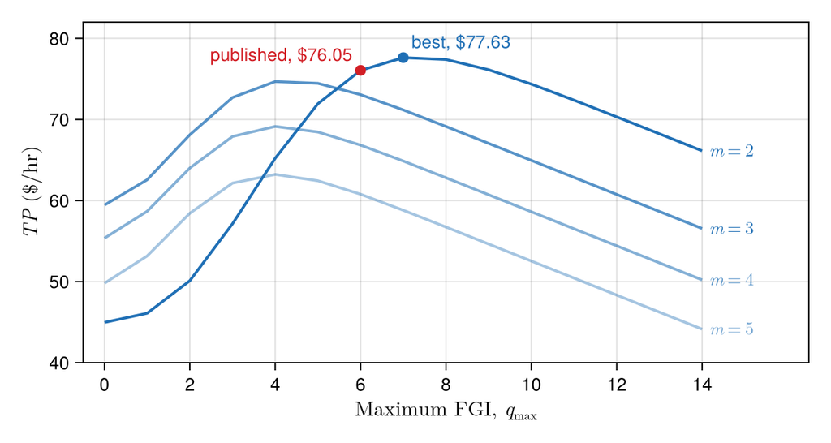

Figure 4: Total profit of Ex. 6’s producer against its maximum finished goods inventory, for two to five machines, determined by Eq. 16, in blue, the darker the fewer machines; the published design, two machines and 6 units, given, in red, and the best, two machines and 7 units. At no inventory, each curve is the make-to-order producer’s total profit, and three machines are the best of those.

```julia
# Code block 23: total profit against the maximum FGI, by machines
bluec = colorant"#1f6fb5"       # determined: total profit
redc = colorant"#d21f26"        # given: the published design
qq = 0:14                       # maximum FGI drawn
alphas = [1.0, 0.75, 0.55, 0.4] # the darker the fewer machines
fig = Figure(size = (600, 320))
ax = Axis(fig[1, 1]; xlabel = L"\text{Maximum FGI, } q_{\max}",
          ylabel = L"TP \text{ (\$/hr)}", xticks = 0:2:14,
          xlabelsize = 15, ylabelsize = 15, xticklabelsize = 13,
          yticklabelsize = 13)
for (i, mi) in enumerate(ms)
    tps = [TPmts(mi, q) for q in qq]
    lines!(ax, qq, tps; color = (bluec, alphas[i]), linewidth = 2)
    text!(ax, qq[end], tps[end]; text = L"m = %$(mi)",
          align = (:left, :center), offset = (5, 0), fontsize = 13,
          color = (bluec, min(1, alphas[i] + 0.2)))  # a shade darker
end
scatter!(ax, [qᵒ], [TPᵒ]; color = bluec, markersize = 11)
text!(ax, qᵒ, TPᵒ; text = "best, \$" * string(round(TPᵒ, digits = 2)),
      align = (:left, :bottom), offset = (6, 4), fontsize = 13,
      color = bluec)
scatter!(ax, [qmax], [TP]; color = redc, markersize = 11)
text!(ax, qmax, TP;
      text = "published, \$" * string(round(TP, digits = 2)),
      align = (:right, :bottom), offset = (-6, 4), fontsize = 13,
      color = redc)
xlims!(ax, -0.5, 16.5)
ylims!(ax, 40, 82)
fig
```

Other maximum levels can be tried by hand. Raised to 12, the total profit goes down; at 10, it goes up a little; and around 6 and 7 it reaches about $76 and then $77. A grid search would calculate every combination automatically, and it is all a function of the number of machines as well. With one machine instead of two, the calculation breaks down: the quantity to look at is the utilization, which is over 100%, violating the cardinal rule, and the minimum number of machines is two. With three machines, the total profit falls to about $71, from $77, and changing the maximum level, even down to 3, leaves it below what two machines make. So two machines with a maximum inventory of 6 or 7 is probably optimal, with $90, the upper bound, the best that could be done.

The search determines which: the best design is 2 machines with a maximum inventory of 7 units, at $77.63 an hour, $1.57 more than the published 6 units. The published design is not the optimum, though the two are close, and the $77 found by trying levels by hand is the best design’s. The best level, 7, is well inside the bound of 20 tried, so the bound need not be doubled. The best total profit is below the upper bound of $90, a Bounds check of Lecture 1.2, at 86% of it.

At no inventory, $q_{\max} = 0$, each curve of Fig. 4 is the make-to-order producer’s, and the best of them is three machines at $59.44 an hour, the make-to-order design of Ex. 3(a), which holds no inventory. Holding finished goods lets the producer run one machine fewer, at a utilization of 0.83, and make $18.19 an hour more: what the inventory buffer adds to the time and capacity buffers.

$m^* =$ 2 machines and $q_{\max}^* =$ 7 units; $TP^*$ = $77.63 per hour, against $76.05 at the published 6 units, $TP_{UB}$ = $90, and $59.44 with no inventory

Example 6(c): Doubled and halved costs

Determine the best design with the delay discount factor doubled and halved, the carrying rate doubled and halved, and the unit capital cost doubled.

Code block 24 runs `maxTPmts` with each change in turn, the rest of the data as given, with the upper bound of Eq. 9 of each:

```julia
# Code block 24: the best design as g, h and k move
labels = ["as given", "g doubled", "g halved", "h doubled", "h halved",
          "k doubled"]
best = [maxTPmts(), maxTPmts(g = 2g), maxTPmts(g = g/2),
        maxTPmts(h = 2h), maxTPmts(h = h/2),
        maxTPmts(k = 2k)]       # ($/hr, machines, maximum FGI) of each
ks = [k, k, k, k, k, 2k]        # $/unit, unit capital cost of each
TPUBs = (p - c .- ks)*rd        # $/hr, upper bound of each
prt([getindex.(best, 2) getindex.(best, 3) getindex.(best, 1) TPUBs];
    rows = labels, cols = ["m*", "qmax*", "TP*", "TP_UB"])
```

```
           m*  qmax*    TP*  TP_UB
──────────────────────────────────
 as given   2      7  77.63     90
g doubled   2      8  76.10     90
 g halved   2      6  79.37     90
h doubled   2      6  70.73     90
 h halved   2      8  82.05     90
k doubled   2      7  65.28     80
```

A backorder’s wait that costs more, $g$ doubled, calls for more stock, 8 units, and one that costs less, $g$ halved, for less, 6; a product that loses its value faster, $h$ doubled, calls for less stock, 6 units, and one that keeps it, $h$ halved, for more, 8. None moves the number of machines. Doubling the unit capital cost leaves the design where it is, at 2 machines and 7 units, but its total profit falls to $65.28 an hour and the upper bound from $90 to $80. Each change moves the design the way it should, a Nudge check of Lecture 1.2.

$q_{\max}^*$ = 8 with $g$ doubled and 6 with $g$ halved; 6 with $h$ doubled and 8 with $h$ halved; with $k$ doubled, the same design at $65.28 per hour, $TP_{UB}$ = $80

### Building ahead

A peak in demand that a service’s customers have to wait through, a make-to-stock producer can meet by building ahead, holding inventory made in the periods before the peak. That is the recursion of Sec. 2 run backward in time. Forward, the work a period cannot finish is carried into the period after it, as a backlog that waits, the time buffer; backward, the demand a period cannot make is carried into the period before it, as inventory built ahead, the inventory buffer. Run from the last period back, the inventory carried into a period from the period before it is the larger of zero and that period’s demand, plus the inventory it must pass on to the period after, less its capacity: the latest-start plan of Lecture 4.3 (Model 2 in Lecture 4.3), which produces each unit as late as capacity allows, so that what one period cannot make is made in the period before it.

## Endnotes

[^1]: The aphorism is generally attributed to the statistician George E. P. Box, who used the phrase “all models are wrong” in a 1976 paper on the limitations of models, and whose longer form, in a 1987 book with Norman Draper, reads: “Essentially, all models are wrong, but some are useful.” George E. P. Box, “Science and statistics,” *Journal of the American Statistical Association* 71, no. 356 (1976): 791–799; George E. P. Box and Norman R. Draper, *Empirical Model-Building and Response Surfaces* (New York: Wiley, 1987); “All models are wrong,” *Wikipedia*, accessed November 16, 2026, https://en.wikipedia.org/wiki/All_models_are_wrong.